# Multiplex Canada Predictive Projection

In this revised version, we compare our main result with a sensitivity analysis with:

- Complete case analysis
- Stratifying HCV and HIV/syphilis
- Model without syphilis (as per reviewer’s request)
- Model with just HIV (as an additional analysis, not included in the manuscript)

To reduce the computational power, only 5-fold cross-validation is used.

Note: the final performance measures may change slightly from the manuscript measures because the sampling frame changes for each run.

## Set-up

```r
knitr::opts_knit$set(root.dir = "~/R files/multiplex canada")
# to ensure that the project is at the root directory
knitr::opts_chunk$set(echo = TRUE, warning = F, fig.width=14, fig.height=18, message = F, verbose = F)
```

### Packages

```r
library(projpred) # main package
library(brms) # for bayesian statistics
library(tidyverse) # for tidy format
library(bayesplot) # to plot bayesian models
theme_set(bayesplot::theme_default(base_family = "sans"))
require(mice)
require(diffobj)
# require(loo)
```

### Load imputed data and functions

```r
source("2_scripts/00_functions.R") # functions
df_imp<- read.csv("3_intermediate/imputed/imputed_data_long_no_prom_1l.csv") #imputed data
mice_obj<- as.mids(df_imp)
```

### Select training vs testing dataset

**imp**

```r
pooled.imp<- complete(mice_obj) # pool imputed data


unique_ids_imp<-unique(pooled.imp$p_id)

# Stratified sampling using dplyr
training_set_imp_all <- pooled.imp %>%
  group_by(site) %>%
  sample_frac(0.75, replace = FALSE) %>%
  ungroup() %>%
  arrange(p_id)

sampled_ids_imp <- training_set_imp_all$p_id

# testing set from the non-selected variables
testing_set_imp_all <- pooled.imp %>%
  filter(!p_id %in% sampled_ids_imp)


## check
length(unique_ids_imp) == length(unique(append(training_set_imp_all$p_id, testing_set_imp_all$p_id)))
```

```
[1] TRUE
```

**CC**

```r
complete.case <-  na.omit(mice_obj$data)# keep rows without missing data


unique_ids<-unique(complete.case$p_id)

# Stratified sampling using dplyr
training_set <- complete.case %>%
  group_by(site) %>% # stratified by site
  sample_frac(0.75, replace = FALSE) %>%
  ungroup() %>%
  arrange(p_id)

sampled_ids <- training_set$p_id

# testing set from the non-selected variables
testing_set <- complete.case %>%
  filter(!p_id %in% sampled_ids)


## check
length(unique_ids) == length(unique(append(training_set$p_id, testing_set $p_id)))
```

```
[1] TRUE
```

### Modify outcomes of interest

**Y=STBBI**

```r
training_set_imp <- training_set_imp_all %>%
  mutate(stbbi.pos = case_when(
    hcv.pos %in% 1~1,
    hiv.pos %in% 1~1,
    syphilis.pos %in% 1 ~1,
    T ~0),
    TypePastSTD = case_when(
      TypePastSTD %in% "None" ~ as.factor(TypePastSTD),
      TypePastSTD %in% "6-Other" ~ "Not specified",
      T ~ "Specified"
    )) %>%
  select(- c(new.hcv, new.syphilis, new.hiv, p_id, Date.Recruited, syphilis.pos, hcv.pos, hiv.pos)) %>%
   mutate_if(is.character, as.factor)


sum1<- summary(training_set_imp)
sum1
```

```
                   SexualActivity   CondomUse     SexualPartners
 0-No or no wish to answer: 84    0-Never: 73   0 to 5   :247
 1-Yes                    :216    1-Ever :227   6 or more: 53




                PastSTD           TypePastSTD                   PastInjectDrugs
 0-No or do not know:169   None         :168   0-No or no wish to answer:185
 1-Yes              :131   Not specified: 16   1-Yes                    :115
                           Specified    :116



 ShareNeedles               Alcohol                           PastHIVTest
 0-No :230    0-No              :160   0-No                         : 41
 1-Yes: 70    1-5 times per week:140   1-Yes; less than 6 months ago:106
                                       2-Yes; 6 months to 1 year ago: 37
                                       3-Yes; more than 1 year ago  :116


                        PastHCVTest                       PastSyphilisTest
 0-No                         : 30   0-No                         :  3
 1-Yes; less than 6 months ago:105   1-Yes; less than 6 months ago: 99
 2-Yes; 6 months to 1 year ago: 37   2-Yes; 6 months to 1 year ago: 35
 3-Yes; more than 1 year ago  :128   3-Yes; more than 1 year ago  :163


              PastSyphilis           Age                Gender
 0-No or do not know:263   18 to 34    :127   1-Male       :216
 1-Yes              : 37   35 and above:173   2-Female     : 63
                                              3-Transgender:  8
                                              5-No response: 13


                                                                    Descent
 Mediterranean European, African, Latin American, Caribbean and/or Asian: 80
 Non-Mediterranean European/North American                              :220




                EducationStatus                  WorkStatus
 4-Post-graduate degree : 93    Currently employed    :142
 No post-graduate degree:207    Not currently employed:158




          MonthlyIncomeStatus CurrentPartner      site        stbbi.pos
 $2000 CAD and above:100      0-No :189      Min.   :0.00   Min.   :0.0000
 1-<$2;000 CAD      :200      1-Yes:111      1st Qu.:0.00   1st Qu.:0.0000
                                             Median :0.00   Median :0.0000
                                             Mean   :0.41   Mean   :0.1867
                                             3rd Qu.:1.00   3rd Qu.:0.0000
                                             Max.   :1.00   Max.   :1.0000
```

```r
testing_set_imp <- testing_set_imp_all %>%
mutate(stbbi.pos = case_when(
    hcv.pos %in% 1~1,
    hiv.pos %in% 1~1,
    syphilis.pos %in% 1 ~1,
    T ~0),
    TypePastSTD = case_when(
      TypePastSTD %in% "None" ~ as.factor(TypePastSTD),
      TypePastSTD %in% "6-Other" ~ "Not specified",
      T ~ "Specified"
    )) %>%
  select(- c(new.hcv, new.syphilis, new.hiv, p_id, Date.Recruited, syphilis.pos, hcv.pos, hiv.pos))  %>%
   mutate_if(is.character, as.factor)

## check

summary(testing_set_imp)
```

```
                   SexualActivity   CondomUse    SexualPartners
 0-No or no wish to answer:23     0-Never:33   0 to 5   :88
 1-Yes                    :77     1-Ever :67   6 or more:12




                PastSTD          TypePastSTD                  PastInjectDrugs
 0-No or do not know:53   None         :55   0-No or no wish to answer:73
 1-Yes              :47   Not specified: 9   1-Yes                    :27
                          Specified    :36



 ShareNeedles               Alcohol                          PastHIVTest
 0-No :82     0-No              :53   0-No                         :16
 1-Yes:18     1-5 times per week:47   1-Yes; less than 6 months ago:35
                                      2-Yes; 6 months to 1 year ago:10
                                      3-Yes; more than 1 year ago  :39


                        PastHCVTest                      PastSyphilisTest
 0-No                         :14   0-No                         : 1
 1-Yes; less than 6 months ago:35   1-Yes; less than 6 months ago:29
 2-Yes; 6 months to 1 year ago:12   2-Yes; 6 months to 1 year ago:12
 3-Yes; more than 1 year ago  :39   3-Yes; more than 1 year ago  :58


              PastSyphilis           Age               Gender
 0-No or do not know:88    18 to 34    :50   1-Male       :68
 1-Yes              :12    35 and above:50   2-Female     :26
                                             3-Transgender: 2
                                             5-No response: 4


                                                                    Descent
 Mediterranean European, African, Latin American, Caribbean and/or Asian:26
 Non-Mediterranean European/North American                              :74




                EducationStatus                  WorkStatus
 4-Post-graduate degree :34     Currently employed    :53
 No post-graduate degree:66     Not currently employed:47




          MonthlyIncomeStatus CurrentPartner      site        stbbi.pos
 $2000 CAD and above:41       0-No :58       Min.   :0.00   Min.   :0.00
 1-<$2;000 CAD      :59       1-Yes:42       1st Qu.:0.00   1st Qu.:0.00
                                             Median :0.00   Median :0.00
                                             Mean   :0.41   Mean   :0.17
                                             3rd Qu.:1.00   3rd Qu.:0.00
                                             Max.   :1.00   Max.   :1.00
```

```r
ncol(testing_set_imp) == ncol(training_set_imp)
```

```
[1] TRUE
```

**Y=HCV**

```r
training_set_hcv <- training_set_imp_all %>%
  mutate(TypePastSTD = case_when(
      TypePastSTD %in% "None" ~ as.factor(TypePastSTD),
      TypePastSTD %in% "6-Other" ~ "Not specified",
      T ~ "Specified"
    )) %>%
  select(- c(new.hcv, new.syphilis, new.hiv, p_id, Date.Recruited, syphilis.pos, hiv.pos)) %>%
   mutate_if(is.character, as.factor)


summary(training_set_hcv)
```

```
                   SexualActivity   CondomUse     SexualPartners
 0-No or no wish to answer: 84    0-Never: 73   0 to 5   :247
 1-Yes                    :216    1-Ever :227   6 or more: 53




                PastSTD           TypePastSTD                   PastInjectDrugs
 0-No or do not know:169   None         :168   0-No or no wish to answer:185
 1-Yes              :131   Not specified: 16   1-Yes                    :115
                           Specified    :116



 ShareNeedles               Alcohol                           PastHIVTest
 0-No :230    0-No              :160   0-No                         : 41
 1-Yes: 70    1-5 times per week:140   1-Yes; less than 6 months ago:106
                                       2-Yes; 6 months to 1 year ago: 37
                                       3-Yes; more than 1 year ago  :116


                        PastHCVTest                       PastSyphilisTest
 0-No                         : 30   0-No                         :  3
 1-Yes; less than 6 months ago:105   1-Yes; less than 6 months ago: 99
 2-Yes; 6 months to 1 year ago: 37   2-Yes; 6 months to 1 year ago: 35
 3-Yes; more than 1 year ago  :128   3-Yes; more than 1 year ago  :163


              PastSyphilis           Age                Gender
 0-No or do not know:263   18 to 34    :127   1-Male       :216
 1-Yes              : 37   35 and above:173   2-Female     : 63
                                              3-Transgender:  8
                                              5-No response: 13


                                                                    Descent
 Mediterranean European, African, Latin American, Caribbean and/or Asian: 80
 Non-Mediterranean European/North American                              :220




                EducationStatus                  WorkStatus
 4-Post-graduate degree : 93    Currently employed    :142
 No post-graduate degree:207    Not currently employed:158




          MonthlyIncomeStatus CurrentPartner    hcv.pos            site
 $2000 CAD and above:100      0-No :189      Min.   :0.0000   Min.   :0.00
 1-<$2;000 CAD      :200      1-Yes:111      1st Qu.:0.0000   1st Qu.:0.00
                                             Median :0.0000   Median :0.00
                                             Mean   :0.1467   Mean   :0.41
                                             3rd Qu.:0.0000   3rd Qu.:1.00
                                             Max.   :1.0000   Max.   :1.00
```

```r
testing_set_hcv <- testing_set_imp_all %>%
  mutate(TypePastSTD = case_when(
      TypePastSTD %in% "None" ~ as.factor(TypePastSTD),
      TypePastSTD %in% "6-Other" ~ "Not specified",
      T ~ "Specified"
    )) %>%
  select(- c(new.hcv, new.syphilis, new.hiv, p_id, Date.Recruited, syphilis.pos, hiv.pos)) %>%
   mutate_if(is.character, as.factor)

## check

summary(testing_set_hcv)
```

```
                   SexualActivity   CondomUse    SexualPartners
 0-No or no wish to answer:23     0-Never:33   0 to 5   :88
 1-Yes                    :77     1-Ever :67   6 or more:12




                PastSTD          TypePastSTD                  PastInjectDrugs
 0-No or do not know:53   None         :55   0-No or no wish to answer:73
 1-Yes              :47   Not specified: 9   1-Yes                    :27
                          Specified    :36



 ShareNeedles               Alcohol                          PastHIVTest
 0-No :82     0-No              :53   0-No                         :16
 1-Yes:18     1-5 times per week:47   1-Yes; less than 6 months ago:35
                                      2-Yes; 6 months to 1 year ago:10
                                      3-Yes; more than 1 year ago  :39


                        PastHCVTest                      PastSyphilisTest
 0-No                         :14   0-No                         : 1
 1-Yes; less than 6 months ago:35   1-Yes; less than 6 months ago:29
 2-Yes; 6 months to 1 year ago:12   2-Yes; 6 months to 1 year ago:12
 3-Yes; more than 1 year ago  :39   3-Yes; more than 1 year ago  :58


              PastSyphilis           Age               Gender
 0-No or do not know:88    18 to 34    :50   1-Male       :68
 1-Yes              :12    35 and above:50   2-Female     :26
                                             3-Transgender: 2
                                             5-No response: 4


                                                                    Descent
 Mediterranean European, African, Latin American, Caribbean and/or Asian:26
 Non-Mediterranean European/North American                              :74




                EducationStatus                  WorkStatus
 4-Post-graduate degree :34     Currently employed    :53
 No post-graduate degree:66     Not currently employed:47




          MonthlyIncomeStatus CurrentPartner    hcv.pos          site
 $2000 CAD and above:41       0-No :58       Min.   :0.00   Min.   :0.00
 1-<$2;000 CAD      :59       1-Yes:42       1st Qu.:0.00   1st Qu.:0.00
                                             Median :0.00   Median :0.00
                                             Mean   :0.16   Mean   :0.41
                                             3rd Qu.:0.00   3rd Qu.:1.00
                                             Max.   :1.00   Max.   :1.00
```

**Y=HIV/S**

```r
training_set_hiv_s <- training_set_imp_all %>%
  mutate(hiv_s_pos = case_when(
    hiv.pos %in% 1~1,
    syphilis.pos %in% 1 ~1,
    T ~0),TypePastSTD = case_when(
      TypePastSTD %in% "None" ~ as.factor(TypePastSTD),
      TypePastSTD %in% "6-Other" ~ "Not specified",
      T ~ "Specified"
    )) %>%
  select(- c(new.hcv, new.syphilis, new.hiv, p_id, Date.Recruited, syphilis.pos, hcv.pos, hiv.pos)) %>%
   mutate_if(is.character, as.factor)

summary(training_set_hiv_s$hiv_s_pos)
```

```
   Min. 1st Qu.  Median    Mean 3rd Qu.    Max.
0.00000 0.00000 0.00000 0.05333 0.00000 1.00000
```

```r
testing_set_hiv_s <- testing_set_imp_all%>%
  mutate(hiv_s_pos = case_when(
    hiv.pos %in% 1~1,
    syphilis.pos %in% 1 ~1,
    T ~0),TypePastSTD = case_when(
      TypePastSTD %in% "None" ~ as.factor(TypePastSTD),
      TypePastSTD %in% "6-Other" ~ "Not specified",
      T ~ "Specified"
    )) %>%
  select(- c(new.hcv, new.syphilis, new.hiv, p_id, Date.Recruited, syphilis.pos, hcv.pos, hiv.pos)) %>%
   mutate_if(is.character, as.factor)

summary(testing_set_hiv_s$hiv_s_pos)
```

```
   Min. 1st Qu.  Median    Mean 3rd Qu.    Max.
   0.00    0.00    0.00    0.02    0.00    1.00
```

**Y=HIV/HCV**

```r
training_set_no_s <- training_set_imp_all %>%
  mutate(hcv_hiv_pos = case_when(
    hcv.pos %in% 1~1,
    hiv.pos %in% 1~1,
    T ~0),
    TypePastSTD = case_when(
      TypePastSTD %in% "None" ~ as.factor(TypePastSTD),
      TypePastSTD %in% "6-Other" ~ "Not specified",
      T ~ "Specified"
    )) %>%
  select(- c(new.hcv, new.syphilis, new.hiv, p_id, Date.Recruited, syphilis.pos, hcv.pos, hiv.pos)) %>%
   mutate_if(is.character, as.factor)


summary(training_set_no_s$hcv_hiv_pos)
```

```
   Min. 1st Qu.  Median    Mean 3rd Qu.    Max.
   0.00    0.00    0.00    0.18    0.00    1.00
```

```r
testing_set_no_s <- testing_set_imp_all %>%
mutate(hcv_hiv_pos = case_when(
    hcv.pos %in% 1~1,
    hiv.pos %in% 1~1,
    T ~0),
    TypePastSTD = case_when(
      TypePastSTD %in% "None" ~ as.factor(TypePastSTD),
      TypePastSTD %in% "6-Other" ~ "Not specified",
      T ~ "Specified"
    )) %>%
  select(- c(new.hcv, new.syphilis, new.hiv, p_id, Date.Recruited, syphilis.pos, hcv.pos, hiv.pos))  %>%
   mutate_if(is.character, as.factor)

## check

summary(testing_set_no_s$hcv_hiv_pos)
```

```
   Min. 1st Qu.  Median    Mean 3rd Qu.    Max.
   0.00    0.00    0.00    0.17    0.00    1.00
```

**Y = HIV**

```r
training_set_hiv <- training_set_imp_all %>%
  mutate(TypePastSTD = case_when(
      TypePastSTD %in% "None" ~ as.factor(TypePastSTD),
      TypePastSTD %in% "6-Other" ~ "Not specified",
      T ~ "Specified"
    )) %>%
  select(- c(new.hcv, new.syphilis, new.hiv, p_id, Date.Recruited, syphilis.pos, hcv.pos)) %>%
   mutate_if(is.character, as.factor)


summary(training_set_hiv)
```

```
                   SexualActivity   CondomUse     SexualPartners
 0-No or no wish to answer: 84    0-Never: 73   0 to 5   :247
 1-Yes                    :216    1-Ever :227   6 or more: 53




                PastSTD           TypePastSTD                   PastInjectDrugs
 0-No or do not know:169   None         :168   0-No or no wish to answer:185
 1-Yes              :131   Not specified: 16   1-Yes                    :115
                           Specified    :116



 ShareNeedles               Alcohol                           PastHIVTest
 0-No :230    0-No              :160   0-No                         : 41
 1-Yes: 70    1-5 times per week:140   1-Yes; less than 6 months ago:106
                                       2-Yes; 6 months to 1 year ago: 37
                                       3-Yes; more than 1 year ago  :116


                        PastHCVTest                       PastSyphilisTest
 0-No                         : 30   0-No                         :  3
 1-Yes; less than 6 months ago:105   1-Yes; less than 6 months ago: 99
 2-Yes; 6 months to 1 year ago: 37   2-Yes; 6 months to 1 year ago: 35
 3-Yes; more than 1 year ago  :128   3-Yes; more than 1 year ago  :163


              PastSyphilis           Age                Gender
 0-No or do not know:263   18 to 34    :127   1-Male       :216
 1-Yes              : 37   35 and above:173   2-Female     : 63
                                              3-Transgender:  8
                                              5-No response: 13


                                                                    Descent
 Mediterranean European, African, Latin American, Caribbean and/or Asian: 80
 Non-Mediterranean European/North American                              :220




                EducationStatus                  WorkStatus
 4-Post-graduate degree : 93    Currently employed    :142
 No post-graduate degree:207    Not currently employed:158




          MonthlyIncomeStatus CurrentPartner    hiv.pos             site
 $2000 CAD and above:100      0-No :189      Min.   :0.00000   Min.   :0.00
 1-<$2;000 CAD      :200      1-Yes:111      1st Qu.:0.00000   1st Qu.:0.00
                                             Median :0.00000   Median :0.00
                                             Mean   :0.04667   Mean   :0.41
                                             3rd Qu.:0.00000   3rd Qu.:1.00
                                             Max.   :1.00000   Max.   :1.00
```

```r
testing_set_hiv <- testing_set_imp_all %>%
  mutate(TypePastSTD = case_when(
      TypePastSTD %in% "None" ~ as.factor(TypePastSTD),
      TypePastSTD %in% "6-Other" ~ "Not specified",
      T ~ "Specified"
    )) %>%
  select(- c(new.hcv, new.syphilis, new.hiv, p_id, Date.Recruited, syphilis.pos, hcv.pos)) %>%
   mutate_if(is.character, as.factor)

## check

summary(testing_set_hiv)
```

```
                   SexualActivity   CondomUse    SexualPartners
 0-No or no wish to answer:23     0-Never:33   0 to 5   :88
 1-Yes                    :77     1-Ever :67   6 or more:12




                PastSTD          TypePastSTD                  PastInjectDrugs
 0-No or do not know:53   None         :55   0-No or no wish to answer:73
 1-Yes              :47   Not specified: 9   1-Yes                    :27
                          Specified    :36



 ShareNeedles               Alcohol                          PastHIVTest
 0-No :82     0-No              :53   0-No                         :16
 1-Yes:18     1-5 times per week:47   1-Yes; less than 6 months ago:35
                                      2-Yes; 6 months to 1 year ago:10
                                      3-Yes; more than 1 year ago  :39


                        PastHCVTest                      PastSyphilisTest
 0-No                         :14   0-No                         : 1
 1-Yes; less than 6 months ago:35   1-Yes; less than 6 months ago:29
 2-Yes; 6 months to 1 year ago:12   2-Yes; 6 months to 1 year ago:12
 3-Yes; more than 1 year ago  :39   3-Yes; more than 1 year ago  :58


              PastSyphilis           Age               Gender
 0-No or do not know:88    18 to 34    :50   1-Male       :68
 1-Yes              :12    35 and above:50   2-Female     :26
                                             3-Transgender: 2
                                             5-No response: 4


                                                                    Descent
 Mediterranean European, African, Latin American, Caribbean and/or Asian:26
 Non-Mediterranean European/North American                              :74




                EducationStatus                  WorkStatus
 4-Post-graduate degree :34     Currently employed    :53
 No post-graduate degree:66     Not currently employed:47




          MonthlyIncomeStatus CurrentPartner    hiv.pos          site
 $2000 CAD and above:41       0-No :58       Min.   :0.00   Min.   :0.00
 1-<$2;000 CAD      :59       1-Yes:42       1st Qu.:0.00   1st Qu.:0.00
                                             Median :0.00   Median :0.00
                                             Mean   :0.02   Mean   :0.41
                                             3rd Qu.:0.00   3rd Qu.:1.00
                                             Max.   :1.00   Max.   :1.00
```

**CC**

```r
training_set <- training_set %>%
  mutate(stbbi.pos = case_when( # create variable for STBBI positive if tested positive for HCV, HIV or syphilis
    hcv.pos %in% 1~1,
    hiv.pos %in% 1~1,
    syphilis.pos %in% 1 ~1,
    T ~0),
    TypePastSTD = case_when( # reduce the number of categories for past type of STIs
      TypePastSTD %in% "None" ~ as.factor(TypePastSTD),
      TypePastSTD %in% "6-Other" ~ "Not specified",
      T ~ "Specified"
    )) %>%
  select(- c(new.hcv, new.syphilis, new.hiv, p_id, Date.Recruited, syphilis.pos, hcv.pos, hiv.pos)) %>%
   mutate_if(is.character, as.factor)

sum2<- summary(training_set)
sum2
```

```
                   SexualActivity   CondomUse     SexualPartners
 0-No or no wish to answer: 53    0-Never: 58   0 to 5   :205
 1-Yes                    :189    1-Ever :184   6 or more: 37




                PastSTD           TypePastSTD                   PastInjectDrugs
 0-No or do not know:138   None         :138   0-No or no wish to answer:163
 1-Yes              :104   Not specified: 16   1-Yes                    : 79
                           Specified    : 88



 ShareNeedles               Alcohol                           PastHIVTest
 0-No :193    0-No              :119   0-No                         : 31
 1-Yes: 49    1-5 times per week:123   1-Yes; less than 6 months ago: 81
                                       2-Yes; 6 months to 1 year ago: 30
                                       3-Yes; more than 1 year ago  :100


                        PastHCVTest                       PastSyphilisTest
 0-No                         : 23   1-Yes; less than 6 months ago: 73
 1-Yes; less than 6 months ago: 78   2-Yes; 6 months to 1 year ago: 29
 2-Yes; 6 months to 1 year ago: 32   3-Yes; more than 1 year ago  :140
 3-Yes; more than 1 year ago  :109


              PastSyphilis           Age                Gender
 0-No or do not know:217   18 to 34    :109   1-Male       :171
 1-Yes              : 25   35 and above:133   2-Female     : 58
                                              3-Transgender:  6
                                              5-No response:  7


                                                                    Descent
 Mediterranean European, African, Latin American, Caribbean and/or Asian: 59
 Non-Mediterranean European/North American                              :183




                EducationStatus                  WorkStatus
 4-Post-graduate degree : 85    Currently employed    :128
 No post-graduate degree:157    Not currently employed:114




          MonthlyIncomeStatus CurrentPartner      site          stbbi.pos
 $2000 CAD and above: 98      0-No :143      Min.   :0.0000   Min.   :0.0000
 1-<$2;000 CAD      :144      1-Yes: 99      1st Qu.:0.0000   1st Qu.:0.0000
                                             Median :0.0000   Median :0.0000
                                             Mean   :0.3636   Mean   :0.1405
                                             3rd Qu.:1.0000   3rd Qu.:0.0000
                                             Max.   :1.0000   Max.   :1.0000
```

```r
testing_set <- testing_set %>%
mutate(stbbi.pos = case_when(
    hcv.pos %in% 1~1,
    hiv.pos %in% 1~1,
    syphilis.pos %in% 1 ~1,
    T ~0),
    TypePastSTD = case_when(
      TypePastSTD %in% "None" ~ as.factor(TypePastSTD),
      TypePastSTD %in% "6-Other" ~ "Not specified",
      T ~ "Specified"
    )) %>%
  select(- c(new.hcv, new.syphilis, new.hiv, p_id, Date.Recruited, syphilis.pos, hcv.pos, hiv.pos))

## check
ncol(testing_set) == ncol(training_set)
```

```
[1] TRUE
```

```r
summary(testing_set)
```

```
 SexualActivity      CondomUse         SexualPartners       PastSTD
 Length:81          Length:81          Length:81          Length:81
 Class :character   Class :character   Class :character   Class :character
 Mode  :character   Mode  :character   Mode  :character   Mode  :character



 TypePastSTD        PastInjectDrugs    ShareNeedles         Alcohol
 Length:81          Length:81          Length:81          Length:81
 Class :character   Class :character   Class :character   Class :character
 Mode  :character   Mode  :character   Mode  :character   Mode  :character



 PastHIVTest        PastHCVTest        PastSyphilisTest   PastSyphilis
 Length:81          Length:81          Length:81          Length:81
 Class :character   Class :character   Class :character   Class :character
 Mode  :character   Mode  :character   Mode  :character   Mode  :character



     Age               Gender            Descent          EducationStatus
 Length:81          Length:81          Length:81          Length:81
 Class :character   Class :character   Class :character   Class :character
 Mode  :character   Mode  :character   Mode  :character   Mode  :character



  WorkStatus        MonthlyIncomeStatus CurrentPartner          site
 Length:81          Length:81           Length:81          Min.   :0.0000
 Class :character   Class :character    Class :character   1st Qu.:0.0000
 Mode  :character   Mode  :character    Mode  :character   Median :0.0000
                                                           Mean   :0.3704
                                                           3rd Qu.:1.0000
                                                           Max.   :1.0000
   stbbi.pos
 Min.   :0.0000
 1st Qu.:0.0000
 Median :0.0000
 Mean   :0.2222
 3rd Qu.:0.0000
 Max.   :1.0000
```

```r
sum(training_set$stbbi.pos) + sum(testing_set$stbbi.pos)
```

```
[1] 52
```

#### differences between Imp and CC distribution

```r
diffPrint(sum1, sum2)
```

```
< sum1
> sum2
@@ 1,5 / 1,5 @@
                     SexualActivity   CondomUse     SexualPartners
<  0-No or no wish to answer: 84    0-Never: 73   0 to 5   :247
>  0-No or no wish to answer: 53    0-Never: 58   0 to 5   :205
<  1-Yes                    :216    1-Ever :227   6 or more: 53
>  1-Yes                    :189    1-Ever :184   6 or more: 37


@@ 7,13 / 7,13 @@

                  PastSTD           TypePastSTD
<  0-No or do not know:169   None         :168
>  0-No or do not know:138   None         :138
<  1-Yes              :131   Not specified: 16
>  1-Yes              :104   Not specified: 16
<                            Specified    :116
>                            Specified    : 88



                    PastInjectDrugs ShareNeedles               Alcohol
<  0-No or no wish to answer:185    0-No :230    0-No              :160
>  0-No or no wish to answer:163    0-No :193    0-No              :119
<  1-Yes                    :115    1-Yes: 70    1-5 times per week:140
>  1-Yes                    : 79    1-Yes: 49    1-5 times per week:123


@@ 21,27 / 21,27 @@

                          PastHIVTest                         PastHCVTest
<  0-No                         : 41   0-No                         : 30
>  0-No                         : 31   0-No                         : 23
<  1-Yes; less than 6 months ago:106   1-Yes; less than 6 months ago:105
>  1-Yes; less than 6 months ago: 81   1-Yes; less than 6 months ago: 78
<  2-Yes; 6 months to 1 year ago: 37   2-Yes; 6 months to 1 year ago: 37
>  2-Yes; 6 months to 1 year ago: 30   2-Yes; 6 months to 1 year ago: 32
<  3-Yes; more than 1 year ago  :116   3-Yes; more than 1 year ago  :128
>  3-Yes; more than 1 year ago  :100   3-Yes; more than 1 year ago  :109
```

[output cut: 48 more lines]

```
<                                              Median :0.00   Median :0.0000
>                                              Median :0.0000
<                                              Mean   :0.41   Mean   :0.1867
>                                              Mean   :0.3636
<                                              3rd Qu.:1.00   3rd Qu.:0.0000
>                                              3rd Qu.:1.0000
>                                              Max.   :1.0000
>    stbbi.pos
>  Min.   :0.0000
>  1st Qu.:0.0000
>  Median :0.0000
>  Mean   :0.1405
>  3rd Qu.:0.0000
<                                              Max.   :1.00   Max.   :1.0000
>  Max.   :1.0000
```

### Fitting a reference model

#### Horseshoe priors

**imp**

```r
# variables
xvar <- training_set_imp %>% select(-c(stbbi.pos)) %>% colnames()

p0 <- 5 # number of relevant non-zero predictor coefficients
# Number of observations:
N <- nrow(training_set_imp)
# number of regression coefficients
D <- length(xvar)
# Hyperprior scale for tau, the global shrinkage parameter (note that for the
# Gaussian family, 'rstanarm' will automatically scale this by the residual
# standard deviation):
tau0 <- p0 / (D - p0) * 1 / sqrt(N)
prior_hs <- horseshoe(scale_global = tau0)
```

**CC**

```r
N2 <- nrow(training_set)
tau0 <- p0 / (D - p0) * 1 / sqrt(N2)
prior_hs_cc <- horseshoe(scale_global = tau0)
```

#### Reference model

**Y=STBBI**

```r
formula <- reformulate(setdiff(c(xvar), "stbbi.pos"), response = "stbbi.pos")


# fit the model
model_imp_hs <- brms::brm(formula,
                   data = training_set_imp,
                  family = bernoulli(link = "logit"),
                   prior = set_prior(prior_hs),
                  seed = 0901,
                  verbose =F,
                  refresh = 0) # prevent sampling progress to be printed
model_imp_hs
```

```
 Family: bernoulli
  Links: mu = logit
Formula: stbbi.pos ~ SexualActivity + CondomUse + SexualPartners + PastSTD + TypePastSTD + PastInjectDrugs + ShareNeedles + Alcohol + PastHIVTest + PastHCVTest + PastSyphilisTest + PastSyphilis + Age + Gender + Descent + EducationStatus + WorkStatus + MonthlyIncomeStatus + CurrentPartner + site
   Data: training_set_imp (Number of observations: 300)
  Draws: 4 chains, each with iter = 2000; warmup = 1000; thin = 1;
         total post-warmup draws = 4000

Population-Level Effects:
                                               Estimate Est.Error l-95% CI
Intercept                                         -3.39      0.81    -5.21
SexualActivity1MYes                                0.00      0.18    -0.38
CondomUse1MEver                                    0.11      0.25    -0.23
SexualPartners6ormore                             -0.06      0.24    -0.72
PastSTD1MYes                                       0.45      0.47    -0.10
TypePastSTDNotspecified                            0.26      0.46    -0.26
TypePastSTDSpecified                               0.04      0.27    -0.55
PastInjectDrugs1MYes                               1.63      0.50     0.56
ShareNeedles1MYes                                  0.03      0.21    -0.38
Alcohol1M5timesperweek                            -0.40      0.41    -1.33
PastHIVTest1MYes;lessthan6monthsago                0.10      0.35    -0.53
PastHIVTest2MYes;6monthsto1yearago                -0.03      0.30    -0.73
PastHIVTest3MYes;morethan1yearago                  0.08      0.26    -0.28
PastHCVTest1MYes;lessthan6monthsago                0.45      0.54    -0.15
PastHCVTest2MYes;6monthsto1yearago                -0.12      0.36    -1.15
PastHCVTest3MYes;morethan1yearago                  0.02      0.25    -0.48
PastSyphilisTest1MYes;lessthan6monthsago           0.04      0.30    -0.56
PastSyphilisTest2MYes;6monthsto1yearago           -0.04      0.30    -0.79
PastSyphilisTest3MYes;morethan1yearago            -0.04      0.27    -0.70
PastSyphilis1MYes                                  0.78      0.64    -0.08
Age35andabove                                      0.07      0.20    -0.24
Gender2MFemale                                    -0.14      0.28    -0.92
Gender3MTransgender                                0.16      0.46    -0.40
Gender5MNoresponse                                 0.20      0.44    -0.31
DescentNonMMediterraneanEuropeanDNorthAmerican    -0.03      0.20    -0.53
EducationStatusNopostMgraduatedegree               0.21      0.35    -0.19
WorkStatusNotcurrentlyemployed                     0.32      0.41    -0.13
MonthlyIncomeStatus1M<$2;000CAD                    0.08      0.25    -0.35
CurrentPartner1MYes                                0.08      0.21    -0.25
site                                               0.09      0.29    -0.35
                                               u-95% CI Rhat Bulk_ESS Tail_ESS
```

[output cut: 19 more lines]

```
PastSyphilis1MYes                                  2.07 1.00     1258     2447
Age35andabove                                      0.60 1.00     3645     4025
Gender2MFemale                                     0.21 1.00     3201     3227
Gender3MTransgender                                1.52 1.00     3225     3356
Gender5MNoresponse                                 1.48 1.00     2848     3360
DescentNonMMediterraneanEuropeanDNorthAmerican     0.37 1.00     4375     3617
EducationStatusNopostMgraduatedegree               1.18 1.00     2499     3492
WorkStatusNotcurrentlyemployed                     1.33 1.00     2110     3326
MonthlyIncomeStatus1M<$2;000CAD                    0.75 1.00     3772     3648
CurrentPartner1MYes                                0.64 1.00     3008     3176
site                                               0.91 1.00     3371     3240

Draws were sampled using sampling(NUTS). For each parameter, Bulk_ESS
and Tail_ESS are effective sample size measures, and Rhat is the potential
scale reduction factor on split chains (at convergence, Rhat = 1).
```

**Y=HCV**

```r
formula_hcv <- reformulate(setdiff(c(xvar), "hcv.pos"), response = "hcv.pos")

model_imp_hcv<- update(model_imp_hs,
        formula_hcv,
        newdata= training_set_hcv,
        verbose = F,
        refresh = 0,
        seed=0901)
```

**Y=HIV/S**

```r
formula_hiv <- reformulate(setdiff(c(xvar), "hiv_s_pos"), response = "hiv_s_pos")

model_imp_hiv_s<- update(model_imp_hs,
        formula_hiv,
        newdata= training_set_hiv_s,
        verbose = F,
        refresh = 0,
        seed=0901)
```

**Y=HIV/HCV**

```r
formula_no_s <- reformulate(setdiff(c(xvar), "hcv_hiv_pos"), response = "hcv_hiv_pos")

model_imp_no_s<- update(model_imp_hs,
        formula_no_s,
        newdata= training_set_no_s,
        verbose = F,
        seed=0901)
```

**Y = HIV**

```r
formula_hiv <- reformulate(setdiff(c(xvar), "hiv.pos"), response = "hiv.pos")

model_imp_hiv<- update(model_imp_hs,
        formula_hiv,
        newdata= training_set_hiv,
        verbose = F,
        seed=0901)
```

**CC**

```r
# set stbbi as response variable
formula <- reformulate(setdiff(c(xvar), "stbbi.pos"), response = "stbbi.pos")

formula
```

```
stbbi.pos ~ SexualActivity + CondomUse + SexualPartners + PastSTD +
    TypePastSTD + PastInjectDrugs + ShareNeedles + Alcohol +
    PastHIVTest + PastHCVTest + PastSyphilisTest + PastSyphilis +
    Age + Gender + Descent + EducationStatus + WorkStatus + MonthlyIncomeStatus +
    CurrentPartner + site
```

```r
# fit the model
model_hs_cc <- update(model_imp_hs,
        formula,
        newdata= training_set,
        verbose = F,
        prior= set_prior(prior_hs_cc),
        seed=0901)
```

#### LOO measures

Empty model

**imp**

```r
require(loo)
model0_imp <- update(model_imp_hs, formula = stbbi.pos ~ 1,  verbose = F, seed=0901)

loo0 <- loo(model0_imp, save_psis = TRUE)
loo0
```

```
Computed from 4000 by 300 log-likelihood matrix

         Estimate   SE
elpd_loo   -145.4 10.0
p_loo         1.0  0.1
looic       290.9 20.0
------
Monte Carlo SE of elpd_loo is 0.0.

All Pareto k estimates are good (k < 0.5).
See help('pareto-k-diagnostic') for details.
```

**CC**

```r
model0_cc <- update(model_hs_cc, formula = stbbi.pos ~ 1,  verbose = F, seed=0901)
loo0_cc <- loo(model0_cc, save_psis = TRUE, seed=0901)
```

**Y=STBBI**

```r
loo_imp_hs <- loo(model_imp_hs, save_psis = TRUE, seed=0901)

loo_imp_hs
```

```
Computed from 4000 by 300 log-likelihood matrix

         Estimate   SE
elpd_loo   -125.1  9.7
p_loo        13.6  1.5
looic       250.2 19.5
------
Monte Carlo SE of elpd_loo is 0.1.

All Pareto k estimates are good (k < 0.5).
See help('pareto-k-diagnostic') for details.
```

```r
loo_compare(loo0, loo_imp_hs)
```

```
             elpd_diff se_diff
model_imp_hs   0.0       0.0
model0_imp   -20.3       5.9
```

**Y=HCV**

```r
loo_imp_hcv <- loo(model_imp_hcv, save_psis = TRUE, seed=0901)

loo_imp_hcv
```

```
Computed from 4000 by 300 log-likelihood matrix

         Estimate   SE
elpd_loo    -99.5  9.8
p_loo         6.8  0.9
looic       199.1 19.6
------
Monte Carlo SE of elpd_loo is 0.1.

Pareto k diagnostic values:
                         Count Pct.    Min. n_eff
(-Inf, 0.5]   (good)     298   99.3%   1284
 (0.5, 0.7]   (ok)         2    0.7%   2597
   (0.7, 1]   (bad)        0    0.0%   <NA>
   (1, Inf)   (very bad)   0    0.0%   <NA>

All Pareto k estimates are ok (k < 0.7).
See help('pareto-k-diagnostic') for details.
```

```r
loo_compare(loo0, loo_imp_hcv)
```

```
              elpd_diff se_diff
model_imp_hcv   0.0       0.0
model0_imp    -45.9       8.0
```

**Y=HIV/S**

```r
loo_imp_hiv_s <- loo(model_imp_hiv_s, save_psis = TRUE, seed=0901)

loo_imp_hiv_s
```

```
Computed from 4000 by 300 log-likelihood matrix

         Estimate   SE
elpd_loo    -50.3  9.8
p_loo         6.4  1.8
looic       100.6 19.5
------
Monte Carlo SE of elpd_loo is 0.1.

Pareto k diagnostic values:
                         Count Pct.    Min. n_eff
(-Inf, 0.5]   (good)     291   97.0%   771
 (0.5, 0.7]   (ok)         9    3.0%   1604
   (0.7, 1]   (bad)        0    0.0%   <NA>
   (1, Inf)   (very bad)   0    0.0%   <NA>

All Pareto k estimates are ok (k < 0.7).
See help('pareto-k-diagnostic') for details.
```

```r
loo_compare(loo0, loo_imp_hiv_s)
```

```
                elpd_diff se_diff
model_imp_hiv_s   0.0       0.0
model0_imp      -95.1      10.7
```

**Y=HIV/HCV**

```r
loo_imp_no_s <- loo(model_imp_no_s, save_psis = TRUE, seed=0901)

loo_imp_no_s
```

```
Computed from 4000 by 300 log-likelihood matrix

         Estimate   SE
elpd_loo   -120.5  9.7
p_loo        12.6  1.4
looic       241.1 19.3
------
Monte Carlo SE of elpd_loo is 0.1.

All Pareto k estimates are good (k < 0.5).
See help('pareto-k-diagnostic') for details.
```

```r
loo_compare(loo0, loo_imp_no_s)
```

```
               elpd_diff se_diff
model_imp_no_s   0.0       0.0
model0_imp     -24.9       6.1
```

**Y = HIV**

```r
loo_imp_hiv <- loo(model_imp_hiv, save_psis = TRUE, seed=0901)

loo_imp_hiv
```

```
Computed from 4000 by 300 log-likelihood matrix

         Estimate   SE
elpd_loo    -45.1  9.3
p_loo         5.0  1.3
looic        90.2 18.7
------
Monte Carlo SE of elpd_loo is 0.1.

Pareto k diagnostic values:
                         Count Pct.    Min. n_eff
(-Inf, 0.5]   (good)     287   95.7%   1100
 (0.5, 0.7]   (ok)        13    4.3%   2104
   (0.7, 1]   (bad)        0    0.0%   <NA>
   (1, Inf)   (very bad)   0    0.0%   <NA>

All Pareto k estimates are ok (k < 0.7).
See help('pareto-k-diagnostic') for details.
```

```r
loo_compare(loo0, loo_imp_hiv)
```

```
              elpd_diff se_diff
model_imp_hiv    0.0       0.0
model0_imp    -100.3      10.7
```

**CC**

```r
loo_cc <- loo(model_hs_cc, save_psis = TRUE)

loo_cc
```

```
Computed from 4000 by 242 log-likelihood matrix

         Estimate   SE
elpd_loo    -83.0  8.9
p_loo        13.3  1.9
looic       166.1 17.8
------
Monte Carlo SE of elpd_loo is 0.1.

All Pareto k estimates are good (k < 0.5).
See help('pareto-k-diagnostic') for details.
```

```r
loo_compare(loo0_cc, loo_cc)
```

```
            elpd_diff se_diff
model_hs_cc   0.0       0.0
model0_cc   -16.2       5.0
```

```r
detach("package:loo", unload=TRUE)
# check that it was removed or else the predictive projection will not work properly
 (.packages())
```

```
 [1] "arsenal"   "pROC"      "caret"     "lattice"   "diffobj"   "mice"
 [7] "bayesplot" "lubridate" "forcats"   "stringr"   "dplyr"     "purrr"
[13] "readr"     "tidyr"     "tibble"    "ggplot2"   "tidyverse" "brms"
[19] "Rcpp"      "projpred"  "stats"     "graphics"  "grDevices" "utils"
[25] "datasets"  "methods"   "base"
```

### Posterior predictive check

**Y=STBBI**

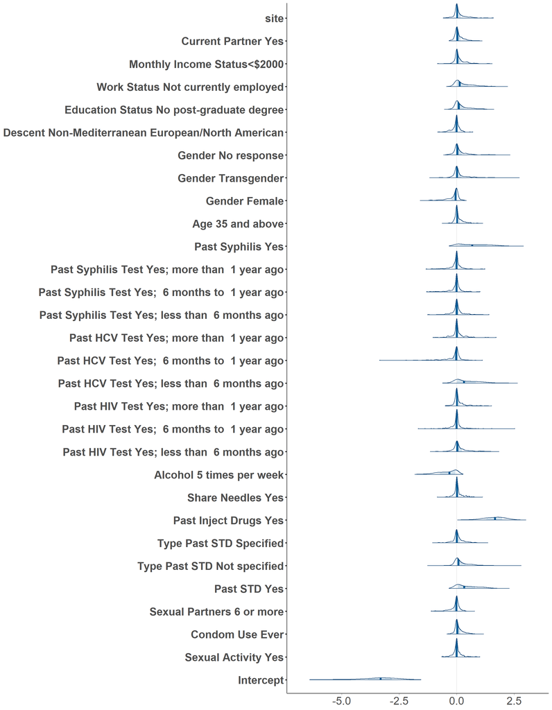

```r
ref_obj_hs<- model_imp_hs

prj_ref <- project(
  ref_obj_hs,
  verbose = F,
  predictor_terms = xvar
  )

# turn into matrix
prj_mat <- as.matrix(prj_ref)

# extract and clean the variable names

col <- colnames(prj_mat)

new_col<- str_replace_all(col, "(b_|\\d+-)| CAD", "") %>%
  str_replace_all("(?<!\\b(?:HCV|HIV|STD|CAD))(?<=\\w)(?=[A-Z])|(?<=\\D)(?=\\d)", " ") %>%
  str_replace_all(" 2; 000", "2000") %>%
  str_replace_all("H I V", "HIV") %>%
  str_replace_all("H C V", "HCV") %>%
  str_replace_all("S T D", "STD")

# to see the posterior distribution of each beta coefficient
mcmc_imp <- mcmc_areas(prj_mat)+
  scale_y_discrete(label= new_col)+ # add new column names
  xaxis_text(size= 20)+
  yaxis_text(size = 20)

mcmc_imp
```

**Y=HCV**

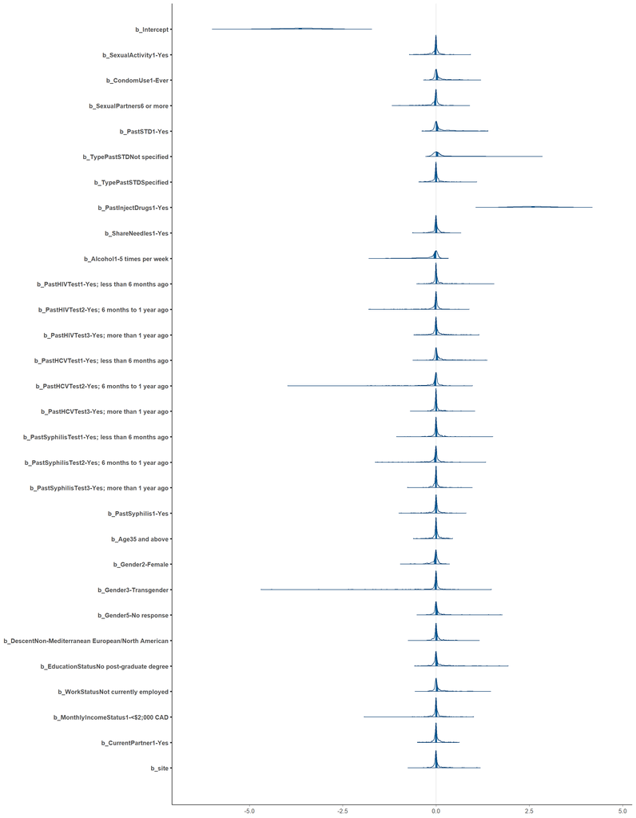

```r
ref_obj_hcv<- model_imp_hcv

prj_ref2 <- project(
  ref_obj_hcv,
  verbose = F,
  predictor_terms = xvar
  )

prj_predict2 <- proj_predict(prj_ref2)

# turn into matrix
prj_mat2 <- as.matrix(prj_ref2)

# to see the posterior distribution of each beta coefficient
mcmc_imp2 <- mcmc_areas(prj_mat2)
mcmc_imp2
```

Posteriors are similar

**Y=HIV/S**

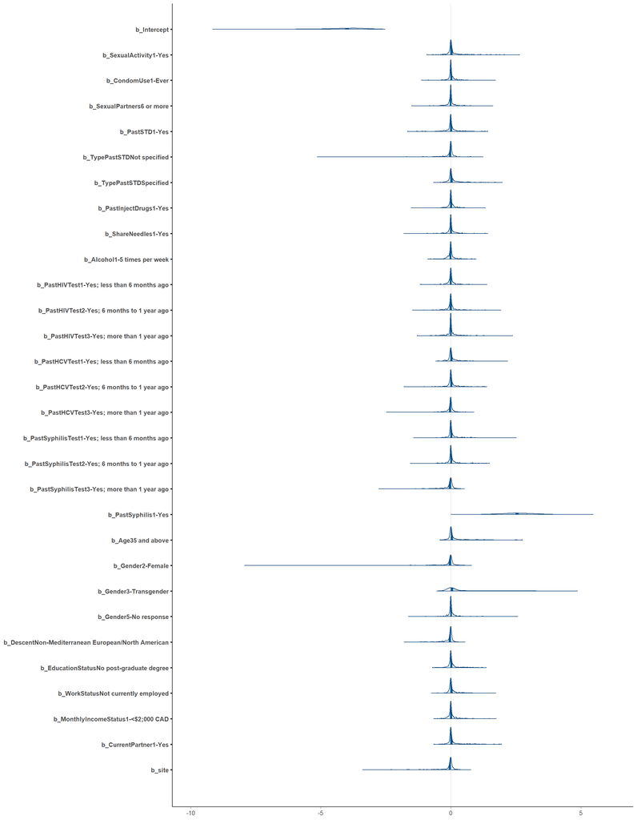

```r
ref_obj_hiv_s<- model_imp_hiv_s

prj_ref3 <- project(
  ref_obj_hiv_s,
  verbose = F,
  predictor_terms = xvar
  )

prj_predict3 <- proj_predict(prj_ref3)

# turn into matrix
prj_mat3 <- as.matrix(prj_ref3)

# to see the posterior distribution of each beta coefficient
mcmc_imp3 <- mcmc_areas(prj_mat3)
mcmc_imp3
```

posteriors are different

**Y = HIV/HCV**

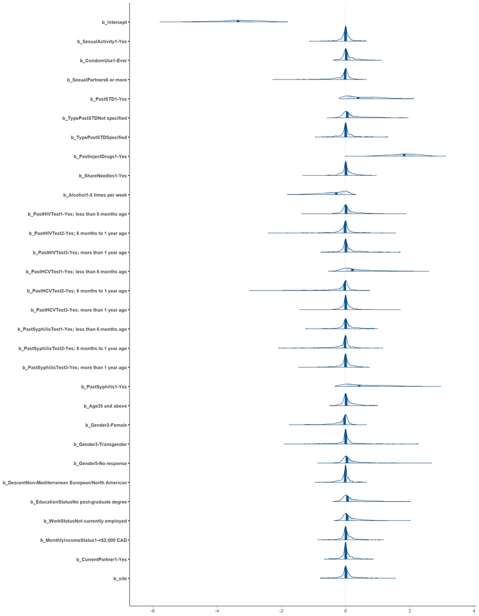

```r
ref_obj_no_s<- model_imp_no_s

prj_ref4 <- project(
  ref_obj_no_s,
  verbose = F,
  predictor_terms = xvar
  )

prj_predict4 <- proj_predict(prj_ref4)

# turn into matrix
prj_mat4 <- as.matrix(prj_ref4)

# to see the posterior distribution of each beta coefficient
mcmc_imp4 <- mcmc_areas(prj_mat4)
mcmc_imp4
```

similar to all except the model without HCV. This shows again that our results are mostly driven by HCV infections.

**Y = HIV**

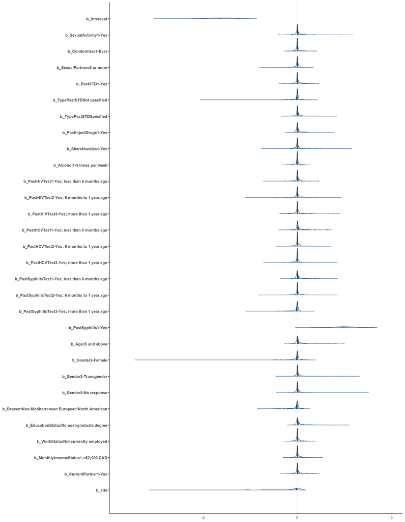

```r
ref_obj_hiv<- model_imp_hiv

prj_ref5 <- project(
  ref_obj_hiv,
  verbose = F,
  predictor_terms = xvar
  )

prj_predict5 <- proj_predict(prj_ref5)

# turn into matrix
prj_mat5 <- as.matrix(prj_ref5)

# to see the posterior distribution of each beta coefficient
mcmc_imp5 <- mcmc_areas(prj_mat5)
mcmc_imp5
```

**CC**

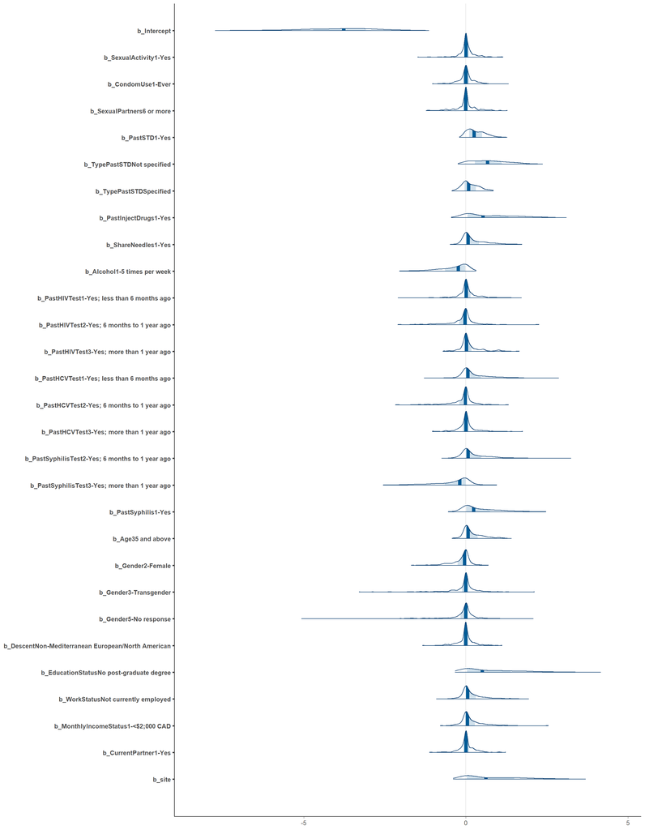

```r
ref_obj_hs<- model_hs_cc

prj_ref <- project(
  ref_obj_hs,
  verbose = F,
  predictor_terms = xvar
  )


# turn into matrix
prj_mat <- as.matrix(prj_ref)

# to see the posterior distribution of each beta coefficient
mcmc_cc <- mcmc_areas(prj_mat)
mcmc_cc
```

### Variable selection

Using 5 fold validation only and set search to 10 max

**Y=STBBI**

```r
cv_fits_imp <- run_cvfun(
  model_imp_hs  # 5k is default
)

# Final cv_varsel() run:
model_imp_nk <- cv_varsel(
  model_imp_hs,
  cv_method = "kfold",
  cv_fits = cv_fits_imp,
  method = "L1",
  nterms_max = 10,
  verbose = F
)

model_imp_nk
```

```
Family: binomial
Link function: logit

Formula: stbbi.pos ~ SexualActivity + CondomUse + SexualPartners + PastSTD +
    TypePastSTD + PastInjectDrugs + ShareNeedles + Alcohol +
    PastHIVTest + PastHCVTest + PastSyphilisTest + PastSyphilis +
    Age + Gender + Descent + EducationStatus + WorkStatus + MonthlyIncomeStatus +
    CurrentPartner + site
Observations: 300
Projection method: traditional
CV method: K-fold CV with K = 5 and search included (i.e., fold-wise searches)
Search method: L1
Maximum submodel size for the search: 10
Number of projected draws in the search: 1 (from clustered projection)
Number of projected draws in the performance evaluation: 400
Argument `refit_prj`: TRUE

Submodel performance evaluation summary with `deltas = FALSE` and `cumulate = FALSE`:
 size    ranking_fulldata cv_proportions_diag elpd elpd.se elpd.diff
    0         (Intercept)                  NA -145     9.9   -22.936
    1     PastInjectDrugs                 1.0 -128     9.7    -6.025
    2         PastHCVTest                 0.4 -128     9.6    -6.020
    3         TypePastSTD                 0.2 -127     9.5    -4.867
    4        PastSyphilis                 0.2 -124     9.4    -2.470
    5             PastSTD                 0.2 -123     9.3    -1.281
    6             Alcohol                 0.2 -122     9.2    -0.483
    7          WorkStatus                 0.2 -122     9.3    -0.107
    8        ShareNeedles                 0.0 -122     9.3    -0.671
    9     EducationStatus                 0.0 -122     9.2     0.109
   10 MonthlyIncomeStatus                 0.2 -122     9.2     0.063
 elpd.diff.se
         5.62
         3.54
         2.57
         2.22
         1.69
         1.40
         1.28
         0.99
         0.87
         0.79
         0.77

Reference model performance evaluation summary with `deltas = FALSE`:
   elpd elpd.se
 -121.8     9.2
```

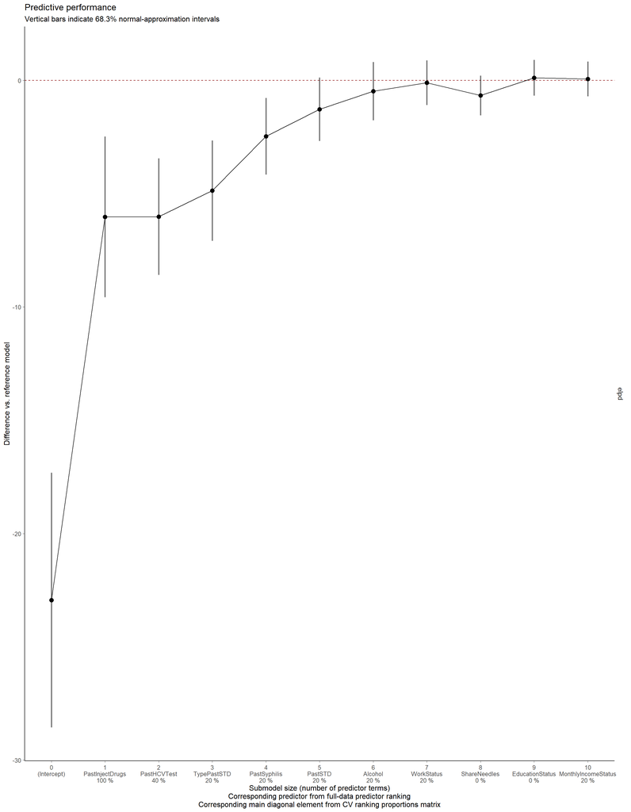

Submodels accuracy using rapid variable selection. Y axis values represent the DIFFERENCE in performance with the reference model. The percentage below each submodel represents the cross-validation ranking of predictors

```r
plot_k5 <- plot(model_imp_nk, stats = "elpd", deltas = TRUE)
plot_k5
```

**Y=HCV**

```r
cv_fits_imp <- run_cvfun(
  model_imp_hcv  # 5k is default
)

model_hcv <- cv_varsel(
  model_imp_hcv,
  cv_method = "kfold",
  cv_fits = cv_fits_imp,
  method = "L1",
  nterms_max = 10,
  verbose = F
)

model_hcv
```

```
Family: binomial
Link function: logit

Formula: hcv.pos ~ SexualActivity + CondomUse + SexualPartners + PastSTD +
    TypePastSTD + PastInjectDrugs + ShareNeedles + Alcohol +
    PastHIVTest + PastHCVTest + PastSyphilisTest + PastSyphilis +
    Age + Gender + Descent + EducationStatus + WorkStatus + MonthlyIncomeStatus +
    CurrentPartner + site
Observations: 300
Projection method: traditional
CV method: K-fold CV with K = 5 and search included (i.e., fold-wise searches)
Search method: L1
Maximum submodel size for the search: 10
Number of projected draws in the search: 1 (from clustered projection)
Number of projected draws in the performance evaluation: 400
Argument `refit_prj`: TRUE

Submodel performance evaluation summary with `deltas = FALSE` and `cumulate = FALSE`:
 size ranking_fulldata cv_proportions_diag elpd elpd.se elpd.diff elpd.diff.se
    0      (Intercept)                  NA -127    11.0    -25.99         6.46
    1  PastInjectDrugs                 1.0 -100     9.6      1.49         1.39
    2      TypePastSTD                 0.6 -101     9.7      0.37         1.21
    3          Alcohol                 0.4 -102    10.0     -0.90         0.68
    4       WorkStatus                 0.0 -102     9.9     -0.31         0.58
    5     ShareNeedles                 0.0 -102     9.9     -0.25         0.55
    6      PastHIVTest                 0.2 -102     9.9     -0.32         0.55
    7      PastHCVTest                 0.0 -102     9.9     -0.11         0.46
    8             site                 0.0 -101     9.8      0.25         0.38
    9        CondomUse                 0.2 -101     9.8      0.26         0.36
   10   SexualActivity                 0.0 -101     9.8      0.30         0.34

Reference model performance evaluation summary with `deltas = FALSE`:
   elpd elpd.se
 -101.5     9.9
```

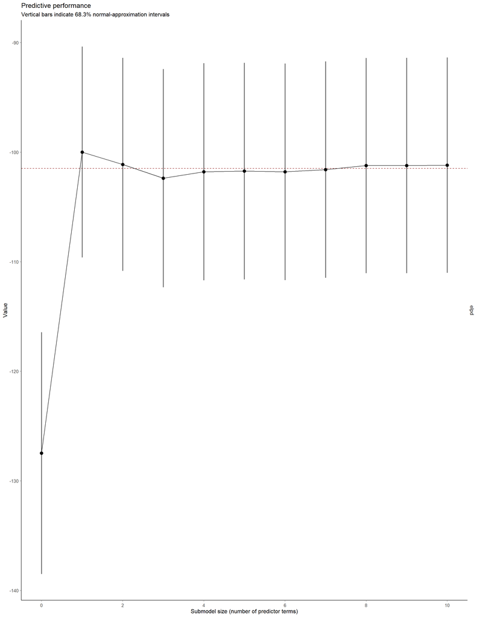

```r
plot(model_hcv, stats = "elpd", ranking_nterms_max = NA)
```

**Y=HIV/S**

```r
cv_fits_imp <- run_cvfun(
  model_imp_hiv_s  # 5k is default
)

model_hiv_s <- cv_varsel(
  model_imp_hiv_s,
  cv_method = "kfold",
  cv_fits = cv_fits_imp,
  method = "L1",
  nterms_max = 10,
  verbose = FALSE, # remove the text
)

model_hiv_s
```

```
Family: binomial
Link function: logit

Formula: hiv_s_pos ~ SexualActivity + CondomUse + SexualPartners + PastSTD +
    TypePastSTD + PastInjectDrugs + ShareNeedles + Alcohol +
    PastHIVTest + PastHCVTest + PastSyphilisTest + PastSyphilis +
    Age + Gender + Descent + EducationStatus + WorkStatus + MonthlyIncomeStatus +
    CurrentPartner + site
Observations: 300
Projection method: traditional
CV method: K-fold CV with K = 5 and search included (i.e., fold-wise searches)
Search method: L1
Maximum submodel size for the search: 10
Number of projected draws in the search: 1 (from clustered projection)
Number of projected draws in the performance evaluation: 400
Argument `refit_prj`: TRUE

Submodel performance evaluation summary with `deltas = FALSE` and `cumulate = FALSE`:
 size    ranking_fulldata cv_proportions_diag elpd elpd.se elpd.diff
    0         (Intercept)                  NA  -64    11.4    -13.48
    1        PastSyphilis                 1.0  -50     9.5      0.83
    2    PastSyphilisTest                 0.8  -50     9.7      0.42
    3              Gender                 0.8  -50     9.7      0.49
    4         TypePastSTD                 0.4  -50     9.8      0.15
    5                site                 0.2  -50     9.9     -0.04
    6         PastHIVTest                 0.0  -51     9.9     -0.32
    7         PastHCVTest                 0.0  -51    10.0     -0.41
    8                 Age                 0.2  -51     9.9     -0.39
    9     EducationStatus                 0.2  -51     9.9     -0.41
   10 MonthlyIncomeStatus                 0.2  -51     9.9     -0.38
 elpd.diff.se
         5.79
         0.81
         0.56
         0.43
         0.39
         0.35
         0.27
         0.27
         0.24
         0.20
         0.19

Reference model performance evaluation summary with `deltas = FALSE`:
   elpd elpd.se
  -50.4     9.8
```

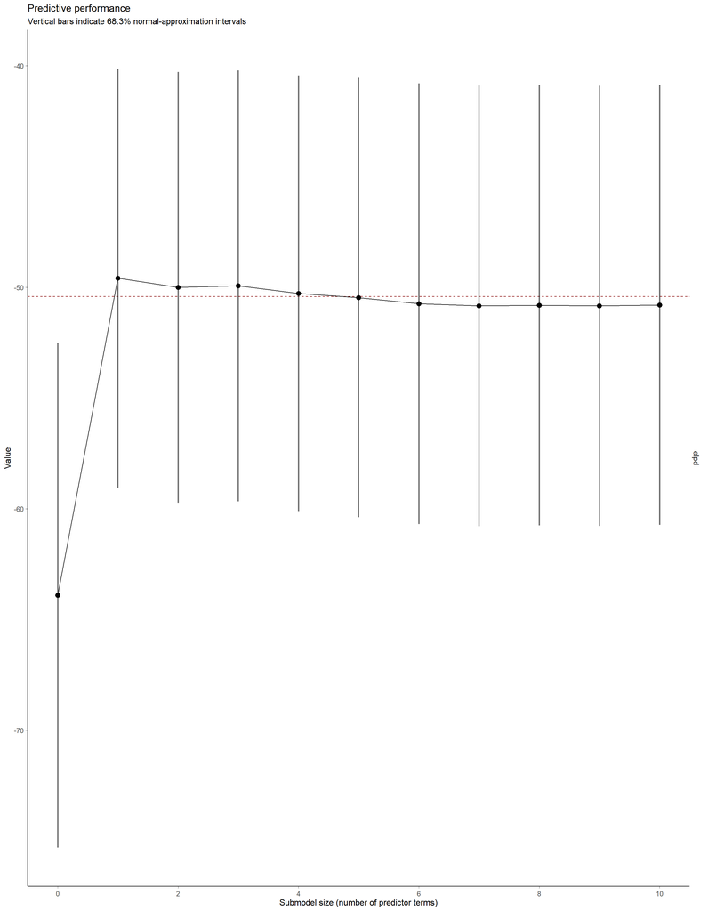

```r
plot(model_hiv_s, stats = "elpd", ranking_nterms_max = NA)
```

**Y = HIV/HCV**

```r
cv_fits_imp <- run_cvfun(
  model_imp_no_s  # 5k is default
)

model_no_s <- cv_varsel(
  model_imp_no_s,
  cv_method = "kfold",
  cv_fits = cv_fits_imp,
  method = "L1",
  nterms_max = 10,
  verbose = FALSE, # remove the text
)

model_no_s
```

```
Family: binomial
Link function: logit

Formula: hcv_hiv_pos ~ SexualActivity + CondomUse + SexualPartners + PastSTD +
    TypePastSTD + PastInjectDrugs + ShareNeedles + Alcohol +
    PastHIVTest + PastHCVTest + PastSyphilisTest + PastSyphilis +
    Age + Gender + Descent + EducationStatus + WorkStatus + MonthlyIncomeStatus +
    CurrentPartner + site
Observations: 300
Projection method: traditional
CV method: K-fold CV with K = 5 and search included (i.e., fold-wise searches)
Search method: L1
Maximum submodel size for the search: 10
Number of projected draws in the search: 1 (from clustered projection)
Number of projected draws in the performance evaluation: 400
Argument `refit_prj`: TRUE

Submodel performance evaluation summary with `deltas = FALSE` and `cumulate = FALSE`:
 size ranking_fulldata cv_proportions_diag elpd elpd.se elpd.diff elpd.diff.se
    0      (Intercept)                  NA -142    10.1   -23.878         5.43
    1  PastInjectDrugs                 1.0 -123     9.7    -4.578         3.02
    2      PastHCVTest                 0.2 -122     9.8    -4.151         2.39
    3      TypePastSTD                 0.2 -121     9.7    -3.021         1.95
    4          PastSTD                 0.0 -119     9.5    -0.543         1.54
    5          Alcohol                 0.4 -118     9.3     0.013         1.28
    6     PastSyphilis                 0.0 -118     9.4     0.380         1.12
    7       WorkStatus                 0.0 -118     9.4     0.295         0.85
    8 PastSyphilisTest                 0.0 -117     9.3     0.878         0.79
    9     ShareNeedles                 0.0 -117     9.3     0.794         0.73
   10  EducationStatus                 0.4 -118     9.3     0.623         0.62

Reference model performance evaluation summary with `deltas = FALSE`:
   elpd elpd.se
 -118.2     9.4
```

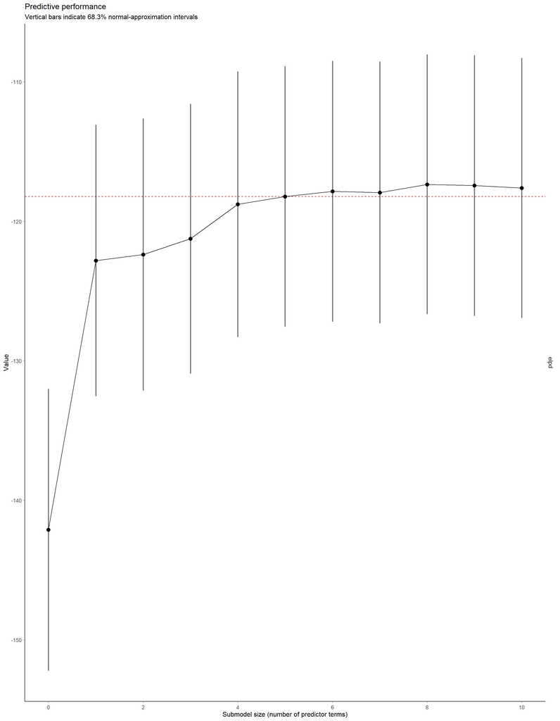

```r
plot(model_no_s, stats = "elpd", ranking_nterms_max = NA)
```

**Y = HIV**

```r
cv_fits_imp <- run_cvfun(
  model_imp_hiv  # 5k is default
)

model_hiv <- cv_varsel(
  model_imp_hiv,
  cv_method = "kfold",
  cv_fits = cv_fits_imp,
  method = "L1",
  nterms_max = 10,
  verbose = F
)

model_hiv
```

```
Family: binomial
Link function: logit

Formula: hiv.pos ~ SexualActivity + CondomUse + SexualPartners + PastSTD +
    TypePastSTD + PastInjectDrugs + ShareNeedles + Alcohol +
    PastHIVTest + PastHCVTest + PastSyphilisTest + PastSyphilis +
    Age + Gender + Descent + EducationStatus + WorkStatus + MonthlyIncomeStatus +
    CurrentPartner + site
Observations: 300
Projection method: traditional
CV method: K-fold CV with K = 5 and search included (i.e., fold-wise searches)
Search method: L1
Maximum submodel size for the search: 10
Number of projected draws in the search: 1 (from clustered projection)
Number of projected draws in the performance evaluation: 400
Argument `refit_prj`: TRUE

Submodel performance evaluation summary with `deltas = FALSE` and `cumulate = FALSE`:
 size ranking_fulldata cv_proportions_diag elpd elpd.se elpd.diff elpd.diff.se
    0      (Intercept)                  NA  -58    11.1    -10.17         4.78
    1     PastSyphilis                 1.0  -47     9.2      0.71         0.64
    2 PastSyphilisTest                 0.8  -47     9.2      0.77         0.49
    3             site                 0.4  -47     9.2      0.89         0.53
    4      TypePastSTD                 0.6  -46     9.2      1.02         0.55
    5          Descent                 0.0  -47     9.2      0.94         0.55
    6              Age                 0.2  -47     9.2      0.72         0.45
    7      PastHCVTest                 0.0  -47     9.3      0.23         0.22
    8  EducationStatus                 0.0  -47     9.3      0.29         0.21
    9           Gender                 0.2  -47     9.3      0.34         0.24
   10   SexualActivity                 0.2  -47     9.3      0.30         0.22

Reference model performance evaluation summary with `deltas = FALSE`:
   elpd elpd.se
  -47.5     9.4
```

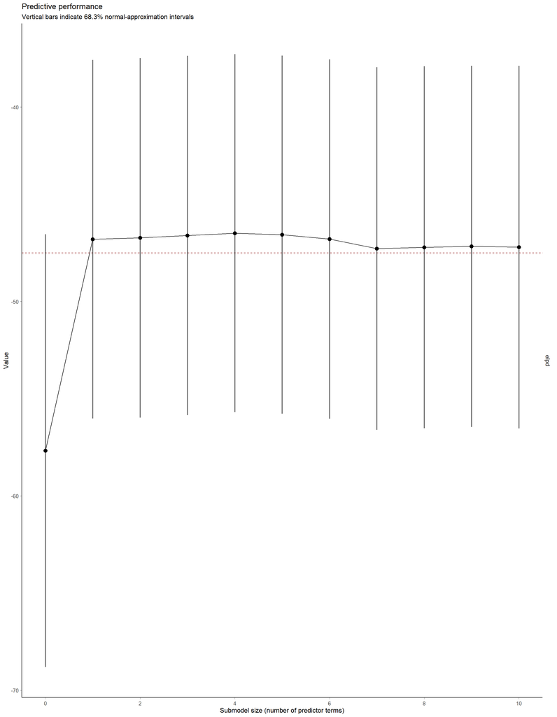

```r
plot(model_hiv, stats = "elpd", ranking_nterms_max = NA)
```

**CC**

```r
cv_fits_imp <- run_cvfun(
  model_hs_cc  # 5k is default
)


model_cc<- cv_varsel(
  model_hs_cc,
  cv_method = "kfold",
  cv_fits = cv_fits_imp,
  method = "L1",
  nterms_max = 10, # faster variable selection
  verbose = FALSE, # remove interactive text
)

model_cc
```

```
Family: binomial
Link function: logit

Formula: stbbi.pos ~ SexualActivity + CondomUse + SexualPartners + PastSTD +
    TypePastSTD + PastInjectDrugs + ShareNeedles + Alcohol +
    PastHIVTest + PastHCVTest + PastSyphilisTest + PastSyphilis +
    Age + Gender + Descent + EducationStatus + WorkStatus + MonthlyIncomeStatus +
    CurrentPartner + site
Observations: 242
Projection method: traditional
CV method: K-fold CV with K = 5 and search included (i.e., fold-wise searches)
Search method: L1
Maximum submodel size for the search: 10
Number of projected draws in the search: 1 (from clustered projection)
Number of projected draws in the performance evaluation: 400
Argument `refit_prj`: TRUE

Submodel performance evaluation summary with `deltas = FALSE` and `cumulate = FALSE`:
 size ranking_fulldata cv_proportions_diag elpd elpd.se elpd.diff elpd.diff.se
    0      (Intercept)                  NA  -98     9.8    -13.80         5.27
    1  PastInjectDrugs                 1.0  -83     9.0      1.20         3.14
    2             site                 0.2  -87     9.3     -2.57         2.53
    3      TypePastSTD                 0.4  -87     9.2     -2.13         2.16
    4     ShareNeedles                 0.2  -86     9.3     -1.53         1.91
    5  EducationStatus                 0.4  -87     9.6     -1.98         1.85
    6          Alcohol                 0.4  -86     9.4     -1.81         1.50
    7       WorkStatus                 0.2  -86     9.2     -1.08         1.19
    8     PastSyphilis                 0.4  -84     9.0      0.55         0.79
    9          PastSTD                 0.2  -84     8.9      0.88         0.81
   10      PastHCVTest                 0.2  -84     8.8      0.94         0.65

Reference model performance evaluation summary with `deltas = FALSE`:
   elpd elpd.se
    -85       9
```

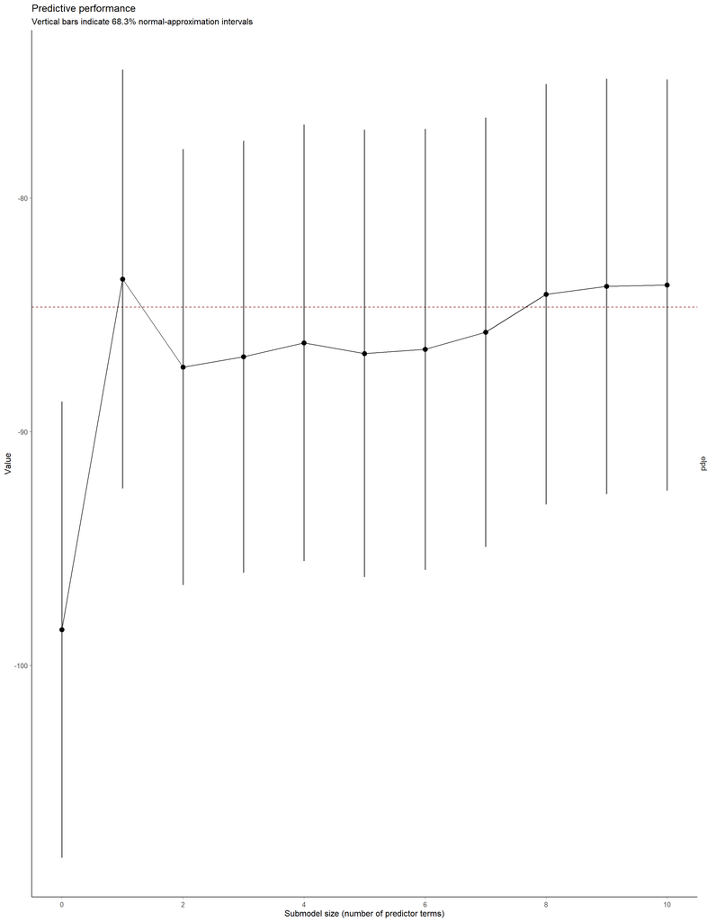

```r
plot(model_cc, stats = "elpd", ranking_nterms_max = NA)  #no ranking based on cross-validation because no cross-validation in this variable selection
```

### Cross-validation results

**Y=STBBI**

```r
ranking_imp <- ranking(model_imp_nk)
```

The predictors are ranked in the following order: PastInjectDrugs, PastHCVTest, TypePastSTD, PastSyphilis, PastSTD, Alcohol, WorkStatus, ShareNeedles, EducationStatus, MonthlyIncomeStatus

**Y=HCV**

```r
ranking_hcv <- ranking(model_hcv)
ranking_hcv[["fulldata"]]
```

```
 [1] "PastInjectDrugs" "TypePastSTD"     "Alcohol"         "WorkStatus"
 [5] "ShareNeedles"    "PastHIVTest"     "PastHCVTest"     "site"
 [9] "CondomUse"       "SexualActivity"
```

**Y=HIV/S**

```r
ranking_hiv_s  <- ranking(model_hiv_s)
ranking_hiv_s[["fulldata"]]
```

```
 [1] "PastSyphilis"        "PastSyphilisTest"    "Gender"
 [4] "TypePastSTD"         "site"                "PastHIVTest"
 [7] "PastHCVTest"         "Age"                 "EducationStatus"
[10] "MonthlyIncomeStatus"
```

**Y=HIV/HCV**

```r
ranking_no_s  <- ranking(model_no_s)
ranking_no_s[["fulldata"]]
```

```
 [1] "PastInjectDrugs"  "PastHCVTest"      "TypePastSTD"      "PastSTD"
 [5] "Alcohol"          "PastSyphilis"     "WorkStatus"       "PastSyphilisTest"
 [9] "ShareNeedles"     "EducationStatus"
```

**Y = HIV**

```r
ranking_hiv <- ranking(model_hiv)
ranking_hiv[["fulldata"]]
```

```
 [1] "PastSyphilis"     "PastSyphilisTest" "site"             "TypePastSTD"
 [5] "Descent"          "Age"              "PastHCVTest"      "EducationStatus"
 [9] "Gender"           "SexualActivity"
```

**CC**

```r
ranking1 <- ranking(model_cc)
ranking1[["fulldata"]]
```

```
 [1] "PastInjectDrugs" "site"            "TypePastSTD"     "ShareNeedles"
 [5] "EducationStatus" "Alcohol"         "WorkStatus"      "PastSyphilis"
 [9] "PastSTD"         "PastHCVTest"
```

### Select model

Will examine all the different sections with the same number of models

**Y=STBBI**

```r
size <- suggest_size(model_imp_nk, stat = "elpd")


predictors_final_imp <- head(ranking_imp[["fulldata"]], 9)
```

The suggested size for the model is 5 with the predictors in the following order PastInjectDrugs, PastHCVTest, TypePastSTD, PastSyphilis, PastSTD, Alcohol, WorkStatus, ShareNeedles, EducationStatus

**Y=HCV**

```r
size2 <- suggest_size(model_hcv, stat = "elpd")


predictors_hcv<- head(ranking_hcv[["fulldata"]], 9)
predictors_hcv
```

```
[1] "PastInjectDrugs" "TypePastSTD"     "Alcohol"         "WorkStatus"
[5] "ShareNeedles"    "PastHIVTest"     "PastHCVTest"     "site"
[9] "CondomUse"
```

The suggested size for the model is 1

**Y=HIV/S**

```r
size3 <- suggest_size(model_hiv_s, stat = "elpd")


predictors_hiv_s<- head(ranking_hiv_s[["fulldata"]], 9)
predictors_hiv_s
```

```
[1] "PastSyphilis"     "PastSyphilisTest" "Gender"           "TypePastSTD"
[5] "site"             "PastHIVTest"      "PastHCVTest"      "Age"
[9] "EducationStatus"
```

The suggested size for the model is 1

**Y=HIV/HCV**

```r
size4 <- suggest_size(model_no_s, stat = "elpd")


predictors_no_s<- head(ranking_no_s[["fulldata"]], 9)
predictors_no_s
```

```
[1] "PastInjectDrugs"  "PastHCVTest"      "TypePastSTD"      "PastSTD"
[5] "Alcohol"          "PastSyphilis"     "WorkStatus"       "PastSyphilisTest"
[9] "ShareNeedles"
```

The suggested size for the model is 4

**Y=HIV**

```r
size5 <- suggest_size(model_hiv, stat = "elpd")


predictors_hiv<- head(ranking_hiv[["fulldata"]], 9)
predictors_hiv
```

```
[1] "PastSyphilis"     "PastSyphilisTest" "site"             "TypePastSTD"
[5] "Descent"          "Age"              "PastHCVTest"      "EducationStatus"
[9] "Gender"
```

The suggested size for the model is 1

**CC**

```r
predictors_final_cc <- head(ranking1[["fulldata"]], 9) # same size as for imputed dataset
predictors_final_cc
```

```
[1] "PastInjectDrugs" "site"            "TypePastSTD"     "ShareNeedles"
[5] "EducationStatus" "Alcohol"         "WorkStatus"      "PastSyphilis"
[9] "PastSTD"
```

### Prediction performance

#### Training data

**Y=STBBI**

```r
# use the submodel function
s1 <- submodels_train(model_imp_hs, predictor_ranking = predictors_final_imp, new_data = training_set_imp)


# measure sensitivity, specificity and AUC using cindy's formula for all models
s1
```

```
[[1]]
 Family: bernoulli
  Links: mu = logit
Formula: stbbi.pos ~ PastInjectDrugs
   Data: training_set_imp (Number of observations: 300)
  Draws: 4 chains, each with iter = 2000; warmup = 1000; thin = 1;
         total post-warmup draws = 4000

Population-Level Effects:
                     Estimate Est.Error l-95% CI u-95% CI Rhat Bulk_ESS
Intercept               -2.37      0.27    -2.94    -1.86 1.00     2502
PastInjectDrugs1MYes     1.73      0.34     1.09     2.40 1.00     3250
                     Tail_ESS
Intercept                2210
PastInjectDrugs1MYes     2743

Draws were sampled using sampling(NUTS). For each parameter, Bulk_ESS
and Tail_ESS are effective sample size measures, and Rhat is the potential
scale reduction factor on split chains (at convergence, Rhat = 1).

[[2]]
 Family: bernoulli
  Links: mu = logit
Formula: stbbi.pos ~ PastInjectDrugs + PastHCVTest
   Data: training_set_imp (Number of observations: 300)
  Draws: 4 chains, each with iter = 2000; warmup = 1000; thin = 1;
         total post-warmup draws = 4000

Population-Level Effects:
                                    Estimate Est.Error l-95% CI u-95% CI Rhat
Intercept                              -2.81      0.46    -3.82    -2.01 1.00
PastInjectDrugs1MYes                    1.89      0.35     1.21     2.59 1.00
PastHCVTest1MYes;lessthan6monthsago     0.84      0.52    -0.01     1.91 1.00
PastHCVTest2MYes;6monthsto1yearago     -0.08      0.40    -1.10     0.71 1.00
PastHCVTest3MYes;morethan1yearago       0.06      0.34    -0.56     0.92 1.00
                                    Bulk_ESS Tail_ESS
Intercept                               2071     2770
PastInjectDrugs1MYes                    3345     2659
PastHCVTest1MYes;lessthan6monthsago     1522      852
PastHCVTest2MYes;6monthsto1yearago      2849     3449
```

[output cut: 318 more lines]

```
PastSyphilis1MYes                                  2.07 1.00     1258     2447
Age35andabove                                      0.60 1.00     3645     4025
Gender2MFemale                                     0.21 1.00     3201     3227
Gender3MTransgender                                1.52 1.00     3225     3356
Gender5MNoresponse                                 1.48 1.00     2848     3360
DescentNonMMediterraneanEuropeanDNorthAmerican     0.37 1.00     4375     3617
EducationStatusNopostMgraduatedegree               1.18 1.00     2499     3492
WorkStatusNotcurrentlyemployed                     1.33 1.00     2110     3326
MonthlyIncomeStatus1M<$2;000CAD                    0.75 1.00     3772     3648
CurrentPartner1MYes                                0.64 1.00     3008     3176
site                                               0.91 1.00     3371     3240

Draws were sampled using sampling(NUTS). For each parameter, Bulk_ESS
and Tail_ESS are effective sample size measures, and Rhat is the potential
scale reduction factor on split chains (at convergence, Rhat = 1).
```

```r
#call colname in each tab
colnames <- c(paste0("model",1:length(predictors_final_imp)), "ref")

s1.sens<- mult.sens(training_set_imp$stbbi.pos, s1) # 2000 iter default
s1.sens
```

```
   rowname       Q50      Q5.5     Q94.5      Q2.5     Q97.5
1   model1 0.8319672 0.7827869 0.8811475 0.7745902 0.8893443
2   model2 0.8401639 0.7950820 0.8852459 0.7827869 0.8934426
3   model3 0.8442623 0.7950820 0.8852459 0.7786885 0.8935451
4   model4 0.8442623 0.7950820 0.8893443 0.7827869 0.8975410
5   model5 0.8442623 0.7950820 0.8893443 0.7827869 0.8975410
6   model6 0.8483607 0.8032787 0.8893443 0.7909836 0.8975410
7   model7 0.8483607 0.8032787 0.8893443 0.7909836 0.9016393
8   model8 0.8483607 0.8032787 0.8934426 0.7868852 0.9016393
9   model9 0.8483607 0.7991803 0.8934426 0.7909836 0.9016393
10     ref 0.8483607 0.7991803 0.8893443 0.7868852 0.8976434
```

```r
s1.spec<- mult.spec(training_set_imp$stbbi.pos, s1) # 2000 iter default
s1.spec
```

```
   rowname       Q50      Q5.5     Q94.5      Q2.5     Q97.5
1   model1 0.2857143 0.1785714 0.3928571 0.1607143 0.4107143
2   model2 0.3035714 0.1785714 0.4107143 0.1607143 0.4285714
3   model3 0.3214286 0.2142857 0.4285714 0.1964286 0.4464286
4   model4 0.3214286 0.2142857 0.4464286 0.1964286 0.4642857
5   model5 0.3214286 0.2142857 0.4295536 0.1785714 0.4647321
6   model6 0.3392857 0.2321429 0.4642857 0.2142857 0.4821429
7   model7 0.3392857 0.2321429 0.4642857 0.2142857 0.4821429
8   model8 0.3392857 0.2321429 0.4642857 0.2142857 0.4821429
9   model9 0.3392857 0.2321429 0.4642857 0.2142857 0.4821429
10     ref 0.3392857 0.2321429 0.4464286 0.1964286 0.4821429
```

```r
s1.auc<- mult.auc(training_set_imp$stbbi.pos, s1)
s1.auc
```

```
   rowname       Q50      Q5.5     Q94.5      Q2.5     Q97.5
1   model1 0.7144321 0.7144321 0.7144321 0.7144321 0.7144321
2   model2 0.7627708 0.7442550 0.7696502 0.6990266 0.7711871
3   model3 0.7823478 0.7524802 0.7903249 0.7398200 0.7923009
4   model4 0.7905079 0.7648485 0.8043033 0.7517546 0.8064275
5   model5 0.7915691 0.7664666 0.8054783 0.7572362 0.8078162
6   model6 0.8063891 0.7840636 0.8183182 0.7761563 0.8201497
7   model7 0.8129757 0.7891174 0.8251244 0.7796655 0.8270291
8   model8 0.8108167 0.7882717 0.8236973 0.7794204 0.8253074
9   model9 0.8118413 0.7875765 0.8275395 0.7784232 0.8299565
10     ref 0.8037178 0.7723500 0.8254944 0.7628421 0.8295905
```

```r
submodels_perf <- bind_rows(s1.sens, s1.spec, s1.auc) %>%
  rename(model = rowname) %>%
  mutate(performance = rep(c("sensitivity", "specificity", "auc"), each=length(colnames)),
         data = "training", outcome="STBBI")
```

**Y=HCV**

```r
s2_train<- submodels_train2(model_imp_hcv, predictor_ranking = predictors_hcv, new_data = training_set_hcv, outcome = "hcv.pos")

colnames <- c(paste0("model",1:length(predictors_hcv)), "ref")


s2.sens<- mult.sens(training_set_hcv$hcv.pos, s2_train) # 2000 iter default

s2.spec<- mult.spec(training_set_hcv$hcv.pos, s2_train) # 2000 iter default2

s2.auc<- mult.auc(training_set_hcv$hcv.pos, s2_train) # 2000 iter default

submodels_perf2 <- bind_rows(s2.sens, s2.spec, s2.auc) %>%
  rename(model = rowname) %>%
  mutate(performance = rep(c("sensitivity", "specificity", "auc"), each=length(colnames)),
         data = "training", outcome="HCV")
```

**Y=HIV/S**

```r
s3_train<- submodels_train2(model_imp_hiv_s, predictor_ranking = predictors_hiv_s, new_data = training_set_hiv_s,  outcome = "hiv_s_pos")

colnames <- c(paste0("model",1:length(predictors_hiv_s)), "ref")

s3.sens<- mult.sens(training_set_hiv_s$hiv_s_pos, s3_train) # 2000 iter default

s3.spec<- mult.spec(training_set_hiv_s$hiv_s_pos, s3_train) # 2000 iter default

s3.auc<- mult.auc(training_set_hiv_s$hiv_s_pos, s3_train) # 2000 iter default


submodels_perf3 <- bind_rows(s3.sens, s3.spec, s3.auc) %>%
  rename(model = rowname) %>%
  mutate(performance = rep(c("sensitivity", "specificity", "auc"), each=length(colnames)),
         data = "training", outcome="HIV/S")
```

**Y=HIV/HCV**

```r
s4_train<- submodels_train2(model_imp_no_s, predictor_ranking = predictors_no_s, new_data = training_set_no_s,  outcome = "hcv_hiv_pos")

colnames <- c(paste0("model",1:length(predictors_no_s)), "ref")

length(colnames) == length(predictors_no_s)+1 # make sure it is always the same size
```

```
[1] TRUE
```

```r
s4.sens<- mult.sens(training_set_no_s$hcv_hiv_pos, s4_train) # 2000 iter default

s4.spec<- mult.spec(training_set_no_s$hcv_hiv_pos, s4_train) # 2000 iter default

s4.auc<- mult.auc(training_set_no_s$hcv_hiv_pos, s4_train) # 2000 iter default


submodels_perf4 <- bind_rows(s4.sens, s4.spec, s4.auc) %>%
  rename(model = rowname) %>%
  mutate(performance = rep(c("sensitivity", "specificity", "auc"), each=length(colnames)),
         data = "training", outcome="HIV/HCV")
```

**Y=HIV**

```r
s5_train<- submodels_train2(model_imp_hiv, predictor_ranking = predictors_hiv, new_data = training_set_hiv,  outcome = "hiv.pos")

colnames <- c(paste0("model",1:length(predictors_hiv)), "ref")

length(colnames) == length(predictors_hiv)+1 # make sure it is always the same size
```

```
[1] TRUE
```

```r
s5.sens<- mult.sens(training_set_hiv$hiv.pos, s5_train) # 2000 iter default

s5.spec<- mult.spec(training_set_hiv$hiv.pos, s5_train) # 2000 iter default

s5.auc<- mult.auc(training_set_hiv$hiv.pos, s5_train) # 2000 iter default


submodels_perf5 <- bind_rows(s5.sens, s5.spec, s5.auc) %>%
  rename(model = rowname) %>%
  mutate(performance = rep(c("sensitivity", "specificity", "auc"), each=length(colnames)),
         data = "training", outcome="HIV")
```

**CC**

```r
# use the submodel function
submodels_cc_train<- submodels_train(model_hs_cc, predictor_ranking = predictors_final_cc, new_data = training_set)


submodels.sens.cc<- mult.sens(training_set$stbbi.pos, submodels_cc_train) # 2000 iter default


submodels.spec.cc<- mult.spec(training_set$stbbi.pos, submodels_cc_train) # 2000 iter default


submodels.auc.cc<- mult.auc(training_set$stbbi.pos, submodels_cc_train)

submodels_perf_cc <- bind_rows(submodels.sens.cc, submodels.spec.cc, submodels.auc.cc) %>%
  rename(model = rowname) %>%
  mutate(performance = rep(c("sensitivity", "specificity", "auc"), each=length(colnames)),
         data = "training", outcome="cc")
```

Combine all values and save to plot later

```r
submodels_perf_fin <- bind_rows(submodels_perf, submodels_perf2, submodels_perf3, submodels_perf4, submodels_perf4, submodels_perf_cc)
```

#### Testing data

We fit our submodels with testing data and extract the sensitivity, specificity and AUC

**Y=STBBI**

```r
s1_test<- submodels_test(s1, new_data = testing_set_imp)

# measure sensitivity, specificity and AUC using cindy's formula for all models
s1_test
```

```
[[1]]
 Family: bernoulli
  Links: mu = logit
Formula: stbbi.pos ~ PastInjectDrugs
   Data: training_set_imp (Number of observations: 300)
  Draws: 4 chains, each with iter = 2000; warmup = 1000; thin = 1;
         total post-warmup draws = 4000

Population-Level Effects:
                     Estimate Est.Error l-95% CI u-95% CI Rhat Bulk_ESS
Intercept               -2.37      0.27    -2.94    -1.86 1.00     2502
PastInjectDrugs1MYes     1.73      0.34     1.09     2.40 1.00     3250
                     Tail_ESS
Intercept                2210
PastInjectDrugs1MYes     2743

Draws were sampled using sampling(NUTS). For each parameter, Bulk_ESS
and Tail_ESS are effective sample size measures, and Rhat is the potential
scale reduction factor on split chains (at convergence, Rhat = 1).

[[2]]
 Family: bernoulli
  Links: mu = logit
Formula: stbbi.pos ~ PastInjectDrugs + PastHCVTest
   Data: training_set_imp (Number of observations: 300)
  Draws: 4 chains, each with iter = 2000; warmup = 1000; thin = 1;
         total post-warmup draws = 4000

Population-Level Effects:
                                    Estimate Est.Error l-95% CI u-95% CI Rhat
Intercept                              -2.81      0.46    -3.82    -2.01 1.00
PastInjectDrugs1MYes                    1.89      0.35     1.21     2.59 1.00
PastHCVTest1MYes;lessthan6monthsago     0.84      0.52    -0.01     1.91 1.00
PastHCVTest2MYes;6monthsto1yearago     -0.08      0.40    -1.10     0.71 1.00
PastHCVTest3MYes;morethan1yearago       0.06      0.34    -0.56     0.92 1.00
                                    Bulk_ESS Tail_ESS
Intercept                               2071     2770
PastInjectDrugs1MYes                    3345     2659
PastHCVTest1MYes;lessthan6monthsago     1522      852
PastHCVTest2MYes;6monthsto1yearago      2849     3449
```

[output cut: 318 more lines]

```
PastSyphilis1MYes                                  2.07 1.00     1258     2447
Age35andabove                                      0.60 1.00     3645     4025
Gender2MFemale                                     0.21 1.00     3201     3227
Gender3MTransgender                                1.52 1.00     3225     3356
Gender5MNoresponse                                 1.48 1.00     2848     3360
DescentNonMMediterraneanEuropeanDNorthAmerican     0.37 1.00     4375     3617
EducationStatusNopostMgraduatedegree               1.18 1.00     2499     3492
WorkStatusNotcurrentlyemployed                     1.33 1.00     2110     3326
MonthlyIncomeStatus1M<$2;000CAD                    0.75 1.00     3772     3648
CurrentPartner1MYes                                0.64 1.00     3008     3176
site                                               0.91 1.00     3371     3240

Draws were sampled using sampling(NUTS). For each parameter, Bulk_ESS
and Tail_ESS are effective sample size measures, and Rhat is the potential
scale reduction factor on split chains (at convergence, Rhat = 1).
```

```r
s1.sens<- mult.sens(testing_set_imp$stbbi.pos, s1_test) # 2000 iter default
s1.sens
```

```
   rowname       Q50      Q5.5     Q94.5      Q2.5    Q97.5
1   model1 0.8795181 0.8072289 0.9277108 0.7831325 0.939759
2   model2 0.8795181 0.8072289 0.9277108 0.7951807 0.939759
3   model3 0.8795181 0.8072289 0.9277108 0.7951807 0.939759
4   model4 0.8795181 0.8192771 0.9277108 0.7951807 0.939759
5   model5 0.8795181 0.8192771 0.9277108 0.7951807 0.939759
6   model6 0.8795181 0.8072289 0.9277108 0.7951807 0.939759
7   model7 0.8795181 0.8186145 0.9277108 0.7951807 0.939759
8   model8 0.8795181 0.8192771 0.9277108 0.7951807 0.939759
9   model9 0.8795181 0.8072289 0.9277108 0.7951807 0.939759
10     ref 0.8795181 0.8072289 0.9397590 0.7951807 0.939759
```

```r
s1.spec<- mult.spec(testing_set_imp$stbbi.pos, s1_test) # 2000 iter default
s1.spec
```

```
   rowname       Q50      Q5.5     Q94.5      Q2.5     Q97.5
1   model1 0.2941176 0.1176471 0.5294118 0.1176471 0.5882353
2   model2 0.3529412 0.1764706 0.5294118 0.1176471 0.5882353
3   model3 0.3529412 0.1764706 0.5882353 0.1764706 0.6470588
4   model4 0.4117647 0.1764706 0.5882353 0.1764706 0.6470588
5   model5 0.4117647 0.2352941 0.5882353 0.1764706 0.6470588
6   model6 0.4117647 0.2352941 0.5882353 0.1764706 0.6470588
7   model7 0.4117647 0.2352941 0.5882353 0.1764706 0.6470588
8   model8 0.4117647 0.2352941 0.5882353 0.1764706 0.6470588
9   model9 0.4117647 0.2352941 0.5882353 0.1764706 0.6470588
10     ref 0.3529412 0.1764706 0.5882353 0.1764706 0.5897059
```

```r
s1.auc<- mult.auc(testing_set_imp$stbbi.pos, s1_test)
s1.auc
```

```
   rowname       Q50      Q5.5     Q94.5      Q2.5     Q97.5
1   model1 0.8688873 0.8688873 0.8688873 0.8688873 0.8688873
2   model2 0.8763288 0.8515237 0.8834160 0.8465627 0.8834160
3   model3 0.8848335 0.8564458 0.9032601 0.8458540 0.9061127
4   model4 0.8834160 0.8550283 0.9068037 0.8458540 0.9131821
5   model5 0.8890858 0.8586109 0.9110560 0.8515237 0.9181432
6   model6 0.8866052 0.8490043 0.9107016 0.8391212 0.9156627
7   model7 0.8897945 0.8515237 0.9153083 0.8422927 0.9195606
8   model8 0.8908575 0.8546740 0.9157016 0.8419561 0.9206237
9   model9 0.8894401 0.8483345 0.9156627 0.8362863 0.9199150
10     ref 0.8887314 0.8433735 0.9192062 0.8263466 0.9241850
```

```r
submodels_perf <- bind_rows(s1.sens, s1.spec, s1.auc) %>%
  rename(model = rowname) %>%
  mutate(performance = rep(c("sensitivity", "specificity", "auc"), each=length(colnames)),
         data = "testing", outcome="STBBI")
```

**Y= HCV**

```r
s2_test<- submodels_test(s2_train, new_data = testing_set_hcv)


s2.sens<- mult.sens(testing_set_hcv$hcv.pos, s2_test) # 2000 iter default

s2.spec<- mult.spec(testing_set_hcv$hcv.pos, s2_test) # 2000 iter default2

s2.auc<- mult.auc(testing_set_hcv$hcv.pos, s2_test)

submodels_perf2 <- bind_rows(s2.sens, s2.spec, s2.auc) %>%
  rename(model = rowname) %>%
  mutate(performance = rep(c("sensitivity", "specificity", "auc"), each=length(colnames)),
         data = "testing", outcome="HCV")
```

**Y=HIV/S**

```r
s3_test<- submodels_test(s3_train, new_data = testing_set_hiv_s)

s3.sens<- mult.sens(testing_set_hiv_s$hiv_s_pos, s3_test) # 2000 iter default

s3.spec<- mult.spec(testing_set_hiv_s$hiv_s_pos, s3_test) # 2000 iter default

s3.auc<- mult.auc(testing_set_hiv_s$hiv_s_pos, s3_test) # 2000 iter default


submodels_perf3 <- bind_rows(s3.sens, s3.spec, s3.auc) %>%
  rename(model = rowname) %>%
  mutate(performance = rep(c("sensitivity", "specificity", "auc"), each=length(colnames)),
         data = "testing", outcome="HIV/S")
```

Specificity remains very similar regardless of model size

Model 2 now has the best AUC but all have acceptable AUC

**Y=HIV/HCV**

```r
s4_test<- submodels_test(s4_train, new_data = testing_set_no_s)


s4.sens<- mult.sens(testing_set_no_s$hcv_hiv_pos, s4_test) # 2000 iter default

s4.spec<- mult.spec(testing_set_no_s$hcv_hiv_pos, s4_test) # 2000 iter default

s4.auc<- mult.auc(testing_set_no_s$hcv_hiv_pos, s4_test) # 2000 iter default


submodels_perf4 <- bind_rows(s4.sens, s4.spec, s4.auc) %>%
  rename(model = rowname) %>%
  mutate(performance = rep(c("sensitivity", "specificity", "auc"), each=length(colnames)),
         data = "testing", outcome="HIV/HCV")
```

**Y = HIV**

```r
s5_test<- submodels_test(s5_train, new_data = testing_set_hiv)


s5.sens<- mult.sens(testing_set_hiv$hiv.pos, s5_test) # 2000 iter default

s5.spec<- mult.spec(testing_set_hiv$hiv.pos, s5_test) # 2000 iter default

s5.auc<- mult.auc(testing_set_hiv$hiv.pos, s5_test) # 2000 iter default


submodels_perf5 <- bind_rows(s5.sens, s5.spec, s5.auc) %>%
  rename(model = rowname) %>%
  mutate(performance = rep(c("sensitivity", "specificity", "auc"), each=length(colnames)),
         data = "testing", outcome="HIV")
```

**CC**

```r
submodels_cc_test<- submodels_test(submodels_cc_train, new_data = testing_set)


submodels.sens.cc<- mult.sens(testing_set$stbbi.pos, submodels_cc_test) # 2000 iter default


submodels.spec.cc<- mult.spec(testing_set$stbbi.pos, submodels_cc_test) # 2000 iter default


submodels.auc.cc<- mult.auc(testing_set$stbbi.pos, submodels_cc_test)

submodels_perf_cc <- bind_rows(submodels.sens.cc, submodels.spec.cc, submodels.auc.cc) %>%
  rename(model = rowname) %>%
  mutate(performance = rep(c("sensitivity", "specificity", "auc"), each=length(colnames)),
         data = "testing", outcome="cc")
```

```r
# combine
submodels_perf_fin <- bind_rows(submodels_perf_fin, submodels_perf, submodels_perf2, submodels_perf3, submodels_perf4, submodels_perf5, submodels_perf_cc)

#save

write.csv(submodels_perf_fin, "3_intermediate/projpred/submodels_performance_SA_rev1.csv", row.names = F)
```

## **Reference:**

Piironen J, Paasiniemi M, Catalina A, Weber F, Vehtari A (2023). “projpred: Projection Predictive Feature Selection.” R package version 2.8.0, https://mc-stan.org/projpred/.

See vignettes for more information